# PROJET

2025-03-25

```r
library("dplyr")
```

```r
pacman::p_load(tidyverse, readr, knitr, kableExtra,FactoMineR,factoextra, ggdendro, vtable, ggstats, scales, broom, ggmosaic, BioStatR, moments)
TB_Burden_Country <- read_csv("TB_Burden_Country.csv")
TB<-TB_Burden_Country
```

on remplace les ” ” par des “_” afin que ce soit plus simple pour les manipulations que l’on va faire

```r
colnames(TB)<- gsub(" ", "_", colnames(TB))
```

```r
TB<-TB%>%select(Country_or_territory_name,`ISO_3-character_country/territory_code`,Region,Year,`Estimated_prevalence_of_TB_(all_forms)_per_100_000_population`,Method_to_derive_prevalence_estimates,`Estimated_mortality_of_TB_cases_(all_forms,_excluding_HIV)_per_100_000_population`,`Estimated_mortality_of_TB_cases_who_are_HIV-positive,_per_100_000_population`,Method_to_derive_mortality_estimates,`Estimated_incidence_(all_forms)_per_100_000_population`,`Case_detection_rate_(all_forms),_percent`)
```

##création variable qualitative région j’ai créé un nouveau tableau TB2 afin d’y mettre les variables qualitatives que j’ai créé

```r
TB2<-TB %>%mutate(region_facteur = factor(Region,levels = c("AFR", "AMR", "EMR", "EUR", "SEA", "WPR")))
```

##creation variable qualitative pour detection case The World Health Organization’s goal for tuberculosis (TB) control is to detect 70% of new, smear-positive TB cases (source: An official website of the United States government: national librar medecine)

```r
TB2<-TB2%>%mutate(det_case= case_when(is.na(`Case_detection_rate_(all_forms),_percent`)~"Non renseignée",`Case_detection_rate_(all_forms),_percent`    <50 ~ "Insuffisant", `Case_detection_rate_(all_forms),_percent`    < 70 ~ "Correct", TRUE ~ "Bon"))
```

##Création variable qualitative pour prevalence derniere et bonne version

```r
etiquettes_deciles <- c("1", "2", "3", "4", "5","6", "7", "8","9", "10")
TB2 <- TB2 %>% mutate(prevalence= cut(`Estimated_prevalence_of_TB_(all_forms)_per_100_000_population`, breaks = quantile(`Estimated_prevalence_of_TB_(all_forms)_per_100_000_population`,probs = seq(0, 1, by = 0.1), na.rm = TRUE), labels=etiquettes_deciles, include.lowest = TRUE))
TB2%>%select(prevalence)
```

```
## # A tibble: 5,120 × 1
##    prevalence
##    <fct>
##  1 8
##  2 8
##  3 9
##  4 9
##  5 9
##  6 9
##  7 9
##  8 9
##  9 9
## 10 9
## # ℹ 5,110 more rows
```

##Création de la variable qualitative pour l’incidence Nous avons utilisé les quantiles et nous avons fait 10 classes et nous l’avons renommé avec etiquettes

```r
# Création des étiquettes pour les déciles (quantiles à 10%)
etiquettes <- c("1", "2", "3", "4", "5","6", "7", "8","9", "10")
# Création d'une variable catégorielle 'incidence' basée sur les déciles de la variable quantitative
TB2 <- TB2 %>% mutate(incidence= cut(`Estimated_incidence_(all_forms)_per_100_000_population` , breaks = quantile(`Estimated_incidence_(all_forms)_per_100_000_population`,probs = seq(0, 1, by = 0.1), na.rm = TRUE), labels=etiquettes, include.lowest = TRUE))
```

```r
TB2 <- TB2 %>%
  select(
    Country_or_territory_name,
    `ISO_3-character_country/territory_code`,
    Region,
    Year,
    `Estimated_prevalence_of_TB_(all_forms)_per_100_000_population`,
    `Estimated_mortality_of_TB_cases_(all_forms,_excluding_HIV)_per_100_000_population`,
    `Estimated_mortality_of_TB_cases_who_are_HIV-positive,_per_100_000_population`,
    `Estimated_incidence_(all_forms)_per_100_000_population`,
    Method_to_derive_mortality_estimates,
    Method_to_derive_prevalence_estimates,
    `Case_detection_rate_(all_forms),_percent`,
    region_facteur,
    det_case,
    prevalence,
    incidence
  )
```

```r
TB2_2000 <- TB2 %>% filter(Year == 2000)
```

```r
glimpse(TB2) #afin de voir tous les titres de notre base de données
```

```
## Rows: 5,120
## Columns: 15
## $ Country_or_territory_name                                                           <chr> …
## $ `ISO_3-character_country/territory_code`                                            <chr> …
## $ Region                                                                              <chr> …
## $ Year                                                                                <dbl> …
## $ `Estimated_prevalence_of_TB_(all_forms)_per_100_000_population`                     <dbl> …
## $ `Estimated_mortality_of_TB_cases_(all_forms,_excluding_HIV)_per_100_000_population` <dbl> …
## $ `Estimated_mortality_of_TB_cases_who_are_HIV-positive,_per_100_000_population`      <dbl> …
## $ `Estimated_incidence_(all_forms)_per_100_000_population`                            <dbl> …
## $ Method_to_derive_mortality_estimates                                                <chr> …
## $ Method_to_derive_prevalence_estimates                                               <chr> …
## $ `Case_detection_rate_(all_forms),_percent`                                          <dbl> …
## $ region_facteur                                                                      <fct> …
## $ det_case                                                                            <chr> …
## $ prevalence                                                                          <fct> …
## $ incidence                                                                           <fct> …
```

#I.1) Analyse univariée quantitative #I.1.1) Calculs de moyenne, médianne, minimum, maximum, variance, écart type, mode et écart interquantile de nos 4 variables quantitatives et tableau récapitulatif:

## calculs de moyennes avec les fonctions de R

```r
moyenne_prevalence<-mean(TB2_2000[["Estimated_prevalence_of_TB_(all_forms)_per_100_000_population"]])
print(paste("La moyenne de la prévalence en 2000 est", moyenne_prevalence))
```

```
## [1] "La moyenne de la prévalence en 2000 est 211.289622641509"
```

```r
moyenne_mortality_non_hiv<-mean(TB2_2000[["Estimated_mortality_of_TB_cases_(all_forms,_excluding_HIV)_per_100_000_population"]])

print(paste("La moyenne de la mortalité sans VIH en 2000 est",moyenne_mortality_non_hiv))
```

```
## [1] "La moyenne de la mortalité sans VIH en 2000 est 22.0182547169811"
```

```r
moyenne_mortality_hiv <- mean(TB2_2000[["Estimated_mortality_of_TB_cases_who_are_HIV-positive,_per_100_000_population"]])
print(paste("La moyenne de la mortalité avec VIH en 2000 est",moyenne_mortality_hiv))
```

```
## [1] "La moyenne de la mortalité avec VIH en 2000 est 16.1241509433962"
```

```r
moyenne_incidence<-mean(TB2_2000[["Estimated_incidence_(all_forms)_per_100_000_population"]])

print(paste("La moyenne de l'incidence en 2000 est",moyenne_incidence))
```

```
## [1] "La moyenne de l'incidence en 2000 est 146.943396226415"
```

##calculs des moyennes sans les fonctions de R

```r
moyenne <- function(data, colonne) {
  # Extraire la colonne comme vecteur
  vecteur <- data[[colonne]]

  # Supprimer les NA
  vecteur <- vecteur[!is.na(vecteur)]

  # Initialiser la somme à 0
  somme <- 0

  # Calculer la somme des valeurs avec une boucle
  for (valeur in vecteur) {
    somme <- somme + valeur
  }

  # Calculer le nombre d'observations valides
  n <- length(vecteur)

  # Calcul de la moyenne
  moyenne <- somme / n

  # Retourner la moyenne
  return(moyenne)
}
```

```r
moyenne_prevalence1<-moyenne(TB2_2000,"Estimated_prevalence_of_TB_(all_forms)_per_100_000_population")
print(paste("La moyenne de la prévalence en 2000 est",moyenne_prevalence1))
```

```
## [1] "La moyenne de la prévalence en 2000 est 211.289622641509"
```

```r
moyenne_mortality_non_hiv1<-moyenne(TB2_2000,"Estimated_mortality_of_TB_cases_(all_forms,_excluding_HIV)_per_100_000_population")
print(paste("La moyenne de la mortalité sans VIH en 2000 est",moyenne_mortality_non_hiv1))
```

```
## [1] "La moyenne de la mortalité sans VIH en 2000 est 22.0182547169811"
```

```r
moyenne_mortality_hiv1<-moyenne(TB2_2000,"Estimated_mortality_of_TB_cases_who_are_HIV-positive,_per_100_000_population")
print(paste("La moyenne de la mortalité avec VIH en 2000 est",moyenne_mortality_hiv1))
```

```
## [1] "La moyenne de la mortalité avec VIH en 2000 est 16.1241509433962"
```

```r
moyenne_incidence1<-moyenne(TB2_2000,"Estimated_incidence_(all_forms)_per_100_000_population")
print(paste("La moyenne de l'incidence en 2000 est",moyenne_incidence1))
```

```
## [1] "La moyenne de l'incidence en 2000 est 146.943396226415"
```

##calculs des médianes avec les fonctions de R

```r
mediane_prevalence<-median(TB2_2000[["Estimated_prevalence_of_TB_(all_forms)_per_100_000_population"]])
print(paste("La médiane de la prévalence en 2000 est",mediane_prevalence))
```

```
## [1] "La médiane de la prévalence en 2000 est 88"
```

```r
mediane_mortality_non_hiv<-
  median(TB2_2000[["Estimated_mortality_of_TB_cases_(all_forms,_excluding_HIV)_per_100_000_population"]])
print(paste("La médiane de la mortalité sans VIH en 2000 est",mediane_mortality_non_hiv))
```

```
## [1] "La médiane de la mortalité sans VIH en 2000 est 5.45"
```

```r
mediane_mortality_hiv<-
  median(TB2_2000[["Estimated_mortality_of_TB_cases_who_are_HIV-positive,_per_100_000_population"]])
print(paste("La médiane de la mortalité avec VIH en 2000 est",mediane_mortality_hiv))
```

```
## [1] "La médiane de la mortalité avec VIH en 2000 est 0.09"
```

```r
mediane_incidence<-
  moyenne_incidence<-median(TB2_2000[["Estimated_incidence_(all_forms)_per_100_000_population"]])
print(paste("La médiane de l'incidence en 2000 est",mediane_incidence))
```

```
## [1] "La médiane de l'incidence en 2000 est 63"
```

##calculs des médianes sans les fonctions de R

```r
mediane <- function(data, colonne) {
  # Extraire  la colonne
  vecteur <- data[[colonne]]
  vecteur <- vecteur[!is.na(vecteur)] #on enlève les NA, car sinon on ne peut pas faire le calcul de plus on a fait le choix de ne pas changer les NA car sinon cela faussera nos résultats et donc nos interprétation

  # Trier le vecteur par ordre croissant
  vecteur <- sort(vecteur)

  # Trouver la longueur
  n <- length(vecteur)

  # Cas impair : valeur du milieu
  if (n %% 2 == 1) {
    med <- vecteur[(n + 1) / 2]
  } else {
    # Cas pair : moyenne des deux du milieu
    milieu1 <- vecteur[n / 2]
    milieu2 <- vecteur[n / 2 + 1]
    med <- (milieu1 + milieu2) / 2
  }

  # Afficher la médiane
  return(med)
}
```

```r
mediane_prevalence1<-mediane(TB2_2000,"Estimated_prevalence_of_TB_(all_forms)_per_100_000_population")
print(paste("La médiane de la prévalence en 2000 est",mediane_prevalence1))
```

```
## [1] "La médiane de la prévalence en 2000 est 88"
```

```r
mediane_mortality_non_hiv1<-mediane(TB2_2000,"Estimated_mortality_of_TB_cases_(all_forms,_excluding_HIV)_per_100_000_population")
print(paste("La médiane de la mortalité sans VIH en 2000 est",mediane_mortality_non_hiv1))
```

```
## [1] "La médiane de la mortalité sans VIH en 2000 est 5.45"
```

```r
mediane_mortality_hiv1<-mediane(TB2_2000,"Estimated_mortality_of_TB_cases_who_are_HIV-positive,_per_100_000_population")
print(paste("La médiane de la mortalité avec VIH en 2000 est",mediane_mortality_hiv1))
```

```
## [1] "La médiane de la mortalité avec VIH en 2000 est 0.09"
```

```r
mediane_incidence1<-mediane(TB2_2000,"Estimated_incidence_(all_forms)_per_100_000_population")
print(paste("La médiane de l'incidence en 2000 est",mediane_incidence1))
```

```
## [1] "La médiane de l'incidence en 2000 est 63"
```

##calculs des valeur minimale avec les fonction intégrées dans R

```r
min_prevalence<-min(TB2_2000[["Estimated_prevalence_of_TB_(all_forms)_per_100_000_population"]])
print(paste("Le minimum de la prévalence en 2000 est",min_prevalence))
```

```
## [1] "Le minimum de la prévalence en 2000 est 0"
```

```r
min_mortality_non_hiv<-min(TB2_2000[["Estimated_mortality_of_TB_cases_(all_forms,_excluding_HIV)_per_100_000_population"]])
print(paste("Le minimum de la mortalité sans VIH en 2000 est",min_mortality_non_hiv))
```

```
## [1] "Le minimum de la mortalité sans VIH en 2000 est 0"
```

```r
min_mortality_hiv<-min(TB2_2000[["Estimated_mortality_of_TB_cases_who_are_HIV-positive,_per_100_000_population"]])
print(paste("Le minimum de la mortalité avec VIH en 2000 est",min_mortality_hiv))
```

```
## [1] "Le minimum de la mortalité avec VIH en 2000 est 0"
```

```r
min_incidence<-min(TB2_2000[["Estimated_incidence_(all_forms)_per_100_000_population"]])
print(paste("Le minimum de l'incidence en 2000 est",min_incidence))
```

```
## [1] "Le minimum de l'incidence en 2000 est 0"
```

##calculs des valeur minimale sans les fonction intégrées dans R

```r
minimum <- function(data, colonne) {
  # Extraire la colonne comme vecteur numérique
  vecteur <- data[[colonne]]

  # Supprimer les NA
  vecteur <- vecteur[!is.na(vecteur)]

  # Initialiser le minimum avec la première valeur
  min_valeur <- vecteur[1]

  # calcule de la longeur du vecteur
  n <- length(vecteur)

  # Parcourir les valeurs restantes pour trouver le minimum
for (i in 1:n) {
    if (vecteur[i] < min_valeur) {
      min_valeur <- vecteur[i]
    }
  }

  # Afficher et retourner le résultat
  return(min_valeur)
}
```

```r
min_prevalence1<-minimum(TB2_2000,"Estimated_prevalence_of_TB_(all_forms)_per_100_000_population")
print(paste("Le minimum de la prévalence en 2000 est",min_prevalence1))
```

```
## [1] "Le minimum de la prévalence en 2000 est 0"
```

```r
min_mortality_non_hiv1<-minimum(TB2_2000,"Estimated_mortality_of_TB_cases_(all_forms,_excluding_HIV)_per_100_000_population")
print(paste("Le minimum de la mortalité sans VIH en 2000 est",min_mortality_non_hiv1))
```

```
## [1] "Le minimum de la mortalité sans VIH en 2000 est 0"
```

```r
min_mortality_hiv1<-minimum(TB2_2000,"Estimated_mortality_of_TB_cases_who_are_HIV-positive,_per_100_000_population")
print(paste("Le minimum de la mortalité avec VIH en 2000 est",min_mortality_hiv1))
```

```
## [1] "Le minimum de la mortalité avec VIH en 2000 est 0"
```

```r
min_incidence1<-minimum(TB2_2000,"Estimated_incidence_(all_forms)_per_100_000_population")
print(paste("Le minimum de l'incidence en 2000 est",min_incidence1))
```

```
## [1] "Le minimum de l'incidence en 2000 est 0"
```

##calculs des valeur maximal avec les fonctions de R

```r
max_prevalence<- max(TB2_2000[["Estimated_prevalence_of_TB_(all_forms)_per_100_000_population"]])
print(paste("Le maximum de la prévalence en 2000 est",max_prevalence))
```

```
## [1] "Le maximum de la prévalence en 2000 est 1623"
```

```r
max_mortality_non_hiv<-
  max(TB2_2000[["Estimated_mortality_of_TB_cases_(all_forms,_excluding_HIV)_per_100_000_population"]])
print(paste("Le maximum de la mortalité sans VIH en 2000 est",max_mortality_non_hiv))
```

```
## [1] "Le maximum de la mortalité sans VIH en 2000 est 191"
```

```r
max_mortality_hiv<-
  max(TB2_2000[["Estimated_mortality_of_TB_cases_who_are_HIV-positive,_per_100_000_population"]])
print(paste("Le maximum de la mortalité avec VIH en 2000 est",max_mortality_hiv))
```

```
## [1] "Le maximum de la mortalité avec VIH en 2000 est 411"
```

```r
max_incidence<-
  max(TB2_2000[["Estimated_incidence_(all_forms)_per_100_000_population"]])
print(paste("Le maximum de l'incidence en 2000 est",max_incidence))
```

```
## [1] "Le maximum de l'incidence en 2000 est 1514"
```

##calculs des valeur maximales sans les fonctions intégrées dans R

```r
maximum <- function(data, colonne) {
  # Extraire la colonne comme vecteur numérique
  vecteur <- data[[colonne]]

  # Supprimer les NA
  vecteur <- vecteur[!is.na(vecteur)]

  # Initialiser le minimum avec la première valeur
  max_valeur <- vecteur[1]

  # calcule de la longeur du vecteur
  n <- length(vecteur)

  # Parcourir les valeurs restantes pour trouver le minimum
for (i in 1:n) {
    if (vecteur[i] > max_valeur) {
      max_valeur <- vecteur[i]
    }
  }

  # Afficher et retourner le résultat
  return(max_valeur)
}
```

```r
max_prevalence1<-maximum(TB2_2000,"Estimated_prevalence_of_TB_(all_forms)_per_100_000_population")
print(paste("Le maximum de la prévalence en 2000 est",max_prevalence1))
```

```
## [1] "Le maximum de la prévalence en 2000 est 1623"
```

```r
max_mortality_non_hiv1<-maximum(TB2_2000,"Estimated_mortality_of_TB_cases_(all_forms,_excluding_HIV)_per_100_000_population")
print(paste("Le maximum de la mortalité sans VIH en 2000 est",max_mortality_non_hiv1))
```

```
## [1] "Le maximum de la mortalité sans VIH en 2000 est 191"
```

```r
max_mortality_hiv1<-maximum(TB2_2000,"Estimated_mortality_of_TB_cases_who_are_HIV-positive,_per_100_000_population")
print(paste("Le maximum de la mortalité avec VIH en 2000 est",max_mortality_hiv1))
```

```
## [1] "Le maximum de la mortalité avec VIH en 2000 est 411"
```

```r
max_incidence1<-maximum(TB2_2000,"Estimated_incidence_(all_forms)_per_100_000_population")
print(paste("Le maximum de l'incidence en 2000 est",max_incidence1))
```

```
## [1] "Le maximum de l'incidence en 2000 est 1514"
```

##calcul de la variance avec les fonctions de R

```r
var_prevalence<-
  var(TB2_2000[["Estimated_prevalence_of_TB_(all_forms)_per_100_000_population"]])

print(paste("La variance de la prévalence en 2000 est", var_prevalence))
```

```
## [1] "La variance de la prévalence en 2000 est 79120.6573325583"
```

```r
var_mortality_non_hiv<-
  var(TB2_2000[["Estimated_mortality_of_TB_cases_(all_forms,_excluding_HIV)_per_100_000_population"]])
print(paste("La variance de la mortalité sans VIH en 2000 est", var_mortality_non_hiv))
```

```
## [1] "La variance de la mortalité sans VIH en 2000 est 1208.57875286372"
```

```r
var_mortality_hiv<-
  var(TB2_2000[["Estimated_mortality_of_TB_cases_who_are_HIV-positive,_per_100_000_population"]])
print(paste("La variance de la mortalité avec VIH en 2000 est", var_mortality_hiv))
```

```
## [1] "La variance de la mortalité avec VIH en 2000 est 3082.14461112403"
```

```r
var_incidence<-
  var(TB2_2000[["Estimated_incidence_(all_forms)_per_100_000_population"]])

print(paste("La variance de l'incidence en 2000 est", var_incidence))
```

```
## [1] "La variance de l'incidence en 2000 est 43704.0656907806"
```

##calcul de la variance sans les fonctions de R

```r
# on sait que la Var(X) = \mathrm{Var}(X) = \frac{1}{n - 1} \sum_{i=1}^{n} (x_i - \bar{x})^2

variance <- function(data, colonne) {
  # Extraire la colonne comme vecteur
  vecteur <- data[[colonne]]

  # Retirer les NA
  vecteur <- vecteur[!is.na(vecteur)]

  # Calcul de la moyenne donc de \bar{x}
  somme <- 0
  n <- length(vecteur)
  for (i in 1:n) {
    somme <- somme + vecteur[i]
  }
  moyenne <- somme / n

  # Calcul de la somme des carrés des écarts à la moyenne donc de sum_{i=1}^{n} (x_i - \bar{x})^2
  somme_ecarts_carre <- 0
  for (i in 1:length(vecteur)) {
    somme_ecarts_carre <- somme_ecarts_carre + (vecteur[i] - moyenne)^2
  }

  # Calcul de la variance
  variance <- somme_ecarts_carre / (length(vecteur) - 1)

  # Retourner la variance
  return(variance)
}
```

```r
var_prevalence1<-variance(TB2_2000,"Estimated_prevalence_of_TB_(all_forms)_per_100_000_population")
print(paste("La variance de la prévalence en 2000 est", var_prevalence1))
```

```
## [1] "La variance de la prévalence en 2000 est 79120.6573325584"
```

```r
var_mortality_non_hiv1<-variance(TB2_2000,"Estimated_mortality_of_TB_cases_(all_forms,_excluding_HIV)_per_100_000_population")
print(paste("La variance de la mortalité sans VIH en 2000 est", var_mortality_non_hiv1))
```

```
## [1] "La variance de la mortalité sans VIH en 2000 est 1208.57875286372"
```

```r
var_mortality_hiv1<-variance(TB2_2000,"Estimated_mortality_of_TB_cases_who_are_HIV-positive,_per_100_000_population")
print(paste("La variance de la mortalité avec VIH en 2000 est", var_mortality_hiv1))
```

```
## [1] "La variance de la mortalité avec VIH en 2000 est 3082.14461112402"
```

```r
var_incidence1<-variance(TB2_2000,"Estimated_incidence_(all_forms)_per_100_000_population")
print(paste("La variance de l'incidence en 2000 est", var_incidence1))
```

```
## [1] "La variance de l'incidence en 2000 est 43704.0656907807"
```

##écart type fonction intégrer dans R

```r
ecart_type_prevalence<-sqrt(var_prevalence)
print(paste("L'écart-type de la prévalence en 2000 est", ecart_type_prevalence))
```

```
## [1] "L'écart-type de la prévalence en 2000 est 281.283944320607"
```

```r
ecart_type_mortality_non_hiv<-sqrt(var_mortality_non_hiv)
print(paste("L'écart-type de la mortalité sans VIH en 2000 est", ecart_type_mortality_non_hiv))
```

```
## [1] "L'écart-type de la mortalité sans VIH en 2000 est 34.7646192682118"
```

```r
ecart_type_mortality_hiv<-sqrt(var_mortality_hiv)
print(paste("L'écart-type de la mortalité avec VIH en 2000 est", ecart_type_mortality_hiv))
```

```
## [1] "L'écart-type de la mortalité avec VIH en 2000 est 55.5170659448428"
```

```r
ecart_type_incidence<-sqrt(var_incidence)
print(paste("L'écart-type de l'incidence en 2000 est", ecart_type_incidence))
```

```
## [1] "L'écart-type de l'incidence en 2000 est 209.055173795773"
```

##écart type des focntion qu’on crée

```r
ecart_type_prevalence1<-sqrt(var_prevalence1)
print(paste("L'écart-type de la prévalence en 2000 est", ecart_type_prevalence1))
```

```
## [1] "L'écart-type de la prévalence en 2000 est 281.283944320607"
```

```r
ecart_type_mortality_non_hiv1<-sqrt(var_mortality_non_hiv1)
print(paste("L'écart-type de la mortalité sans VIH en 2000 est", ecart_type_mortality_non_hiv1))
```

```
## [1] "L'écart-type de la mortalité sans VIH en 2000 est 34.7646192682118"
```

```r
ecart_type_mortality_hiv1<-sqrt(var_mortality_hiv1)
print(paste("L'écart-type de la mortalité avec VIH en 2000 est", ecart_type_mortality_hiv1))
```

```
## [1] "L'écart-type de la mortalité avec VIH en 2000 est 55.5170659448428"
```

```r
ecart_type_incidence1<-sqrt(var_incidence1)
print(paste("L'écart-type de l'incidence en 2000 est", ecart_type_incidence1))
```

```
## [1] "L'écart-type de l'incidence en 2000 est 209.055173795773"
```

##La mode de la distribution d’une variable l’observation la plus fréquente. Elle est applicable à toutes les variables :

```r
mode_incidence <- TB2_2000 %>% count("Estimated_incidence_(all_forms)_per_100_000_population") %>% arrange (desc(n))%>% filter (n == max(n)) %>% pull()

print(paste("La mode de l'incidence en 2000 est",mode_incidence))
```

```
## [1] "La mode de l'incidence en 2000 est 212"
```

```r
mode_mortality_non_hiv <- TB2_2000 %>% count("Estimated_mortality_of_TB_cases_(all_forms,_excluding_HIV)_per_100_000_population") %>% arrange (desc(n))%>% filter (n == max(n)) %>% pull()

print(paste("La mode de la mortalité sans VIH en 2000 est",mode_mortality_non_hiv))
```

```
## [1] "La mode de la mortalité sans VIH en 2000 est 212"
```

```r
mode_mortality_hiv <- TB2_2000 %>% count("Estimated_mortality_of_TB_cases_who_are_HIV-positive,_per_100_000_population") %>% arrange (desc(n))%>% filter (n == max(n)) %>% pull()

print(paste("La mode de la mortalité avec VIH en 2000 est",mode_mortality_hiv))
```

```
## [1] "La mode de la mortalité avec VIH en 2000 est 212"
```

```r
mode_prevalence <- TB2_2000 %>% count("Estimated_prevalence_of_TB_(all_forms)_per_100_000_population") %>% arrange (desc(n))%>% filter (n == max(n)) %>% pull()

print(paste("La mode de la prévalence en 2000 est",mode_prevalence))
```

```
## [1] "La mode de la prévalence en 2000 est 212"
```

## L’écart interquartile

```r
iqr_prevalence <- IQR(TB2_2000$`Estimated_prevalence_of_TB_(all_forms)_per_100_000_population`)

print(paste("L'écart interquartile de la mortalité avec VIH en 2000 est", iqr_prevalence))
```

```
## [1] "L'écart interquartile de la mortalité avec VIH en 2000 est 313.25"
```

```r
iqr_mortality_hiv<-IQR(TB2_2000$`Estimated_mortality_of_TB_cases_who_are_HIV-positive,_per_100_000_population`)

print(paste("L'écart interquartile de la mortalité avec VIH en 2000 est", iqr_mortality_hiv))
```

```
## [1] "L'écart interquartile de la mortalité avec VIH en 2000 est 3.125"
```

```r
iqr_mortality_non_hiv<-IQR(TB2_2000$`Estimated_mortality_of_TB_cases_(all_forms,_excluding_HIV)_per_100_000_population`)

print(paste("L'écart interquartile de la mortalité sans VIH en 2000 est", iqr_mortality_non_hiv))
```

```
## [1] "L'écart interquartile de la mortalité sans VIH en 2000 est 22.825"
```

```r
iqr_incidence<-IQR(TB2_2000$`Estimated_incidence_(all_forms)_per_100_000_population`)
print(paste("L'écart interquartile de l'incidence en 2000 est", iqr_incidence))
```

```
## [1] "L'écart interquartile de l'incidence en 2000 est 173.25"
```

Tout d’abord vérifions que les indicateurs calculer avec nos fonctions donnent le même résultat que les fonctions déjà présente sur R pour la moyenne, la médiane, le minimum, le maximum, la variance et l’écart-type. Pour ce faire on va utiliser la fonction native de R ” all.equal()” qui permet de comparer de manière tolérente les nombres.

*Attention* *Les variables des fonctions qu’on a créé se terminent par un 1*

```r
#Vérification pour la moyenne
all.equal(c(moyenne_prevalence,moyenne_mortality_non_hiv, moyenne_mortality_hiv, moyenne_incidence ),c(moyenne_prevalence1,moyenne_mortality_non_hiv1, moyenne_mortality_hiv1, moyenne_incidence1 ) )
```

```
## [1] "Mean relative difference: 0.2686773"
```

```r
#vérification pour la médiane
all.equal(c(mediane_prevalence, mediane_mortality_non_hiv, mediane_mortality_hiv, mediane_incidence),
c(mediane_prevalence1, mediane_mortality_non_hiv1, mediane_mortality_hiv1, mediane_incidence1)
 )
```

```
## [1] TRUE
```

```r
#vérification pour le max
all.equal(c(max_prevalence, max_mortality_non_hiv, max_mortality_hiv, max_incidence),
c(max_prevalence1, max_mortality_non_hiv1, max_mortality_hiv1, max_incidence1))
```

```
## [1] TRUE
```

```r
# vérification pour le min
all.equal(c(min_prevalence, min_mortality_non_hiv, min_mortality_hiv, min_incidence),
c(min_prevalence1, min_mortality_non_hiv1, min_mortality_hiv1, min_incidence1))
```

```
## [1] TRUE
```

```r
# vérification pour la variance
all.equal(c(var_prevalence, var_mortality_non_hiv, var_mortality_hiv, var_incidence),
c(var_prevalence1, var_mortality_non_hiv1, var_mortality_hiv1, var_incidence1))
```

```
## [1] TRUE
```

```r
# vérification pour l'écart type
all.equal(c(ecart_type_prevalence, ecart_type_mortality_non_hiv, ecart_type_mortality_hiv, ecart_type_incidence),
c(ecart_type_prevalence1, ecart_type_mortality_non_hiv1, ecart_type_mortality_hiv1, ecart_type_incidence1))
```

```
## [1] TRUE
```

Créons maintenant le tableau récapitulatif

```r
# On crée le tableau de départ
resume<- data.frame(

  # première colonne
  Indicateurs = c("Minimum",
                  "Maximum",
                  "Moyenne",
                  "Médiane",
                  "Variance",
                  "Ecart type",
                  "Mode",
                  "Ecart interquartile"),

  # deuxième  colonne
  Prevalence= c(min_prevalence,
                max_prevalence,
                moyenne_prevalence,
                mediane_prevalence,
                var_prevalence,
                ecart_type_prevalence,
                mode_prevalence,
                iqr_prevalence),

  # troisème colonne
  Incidence = c(min_incidence,
                max_incidence,
                moyenne_incidence,
                mediane_incidence,
                var_incidence,
                ecart_type_incidence,
                mode_incidence,
                iqr_incidence
                ),

  #quatrième colonne
  Mortalité_avec_vih = c(min_mortality_hiv,
                         max_mortality_hiv,
                         moyenne_mortality_hiv,
                         mediane_mortality_hiv,
                         var_mortality_hiv,
                         ecart_type_mortality_hiv,
                         mode_mortality_hiv,
                         iqr_mortality_hiv),

  #dernière colonne
  Mortalité_sans_vih = c(min_mortality_non_hiv,
                         max_mortality_non_hiv,
                         moyenne_mortality_non_hiv,
                         mediane_mortality_non_hiv,
                         var_mortality_non_hiv,
                      ecart_type_mortality_non_hiv,
                      mode_mortality_non_hiv,
                      iqr_mortality_non_hiv))




# on stylise le tableau

resume%>%

   # On crée un beau tableau avec des bordures et un titre
   kable(booktabs = TRUE, caption = "Synthèse des indicateurs calculés" ) %>%

  # On ne veut pas que le tableau s'étire sur toute la longueur donc on le centre et on choisit une taille de police
  kable_styling(full_width = FALSE, position = "center", font_size = 12, ) %>%

  # On met la première colonne en gras
  column_spec(1, bold = TRUE)%>%

  # On met l'entête du tableau en gras et on la centre
  row_spec(0, bold = TRUE, align = "center")
```

Synthèse des indicateurs calculés

[output not shown]

#I.1.2) Analyse univariée de l’incidence ## Histogramme de l’incidence :

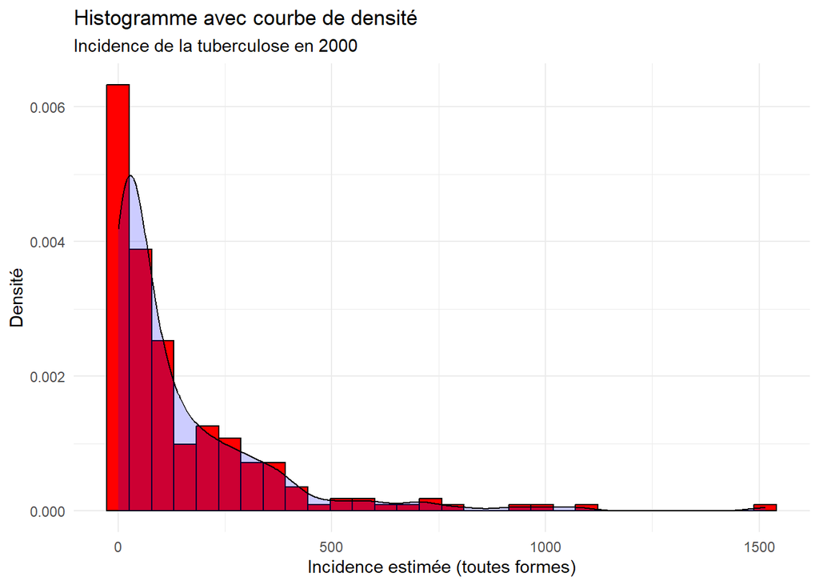

```r
#Estimated_incidence_(all_forms)_per_100_000_population

TB2_2000 %>% #data que pour l'année 2000

  ggplot() + #initiation du graphique

  aes( # indique la correspondance entre les variables de notre tables et les esthétiques du graphique
    x = `Estimated_incidence_(all_forms)_per_100_000_population`, #variable  placée en abscice
    y = after_stat(density)) +   # calcule automatiquement la densité pour l'ordonné

  geom_histogram( #géométrie de l'histogramme
    color = "black",# les contours de l'histogramme sont noirs
    fill = "red") +  # les barres de l'histogramme sont remplis en  rouges

  geom_density( # géométrie de la densité
    alpha = 0.2 # transparence de la zone sous la courbe de densité
    , fill = "blue") + # la zone sous la coube de densité est bleu

  labs( # labels : permet d'ajouter ou de modifier les titres et les étiques du graphique
    title = "Histogramme avec courbe de densité", #titre
    subtitle = "Incidence de la tuberculose en 2000", #sous titre
    x = "Incidence estimée (toutes formes)", # nom affiché sur l'axe des abscisses
    y = "Densité") + #nom affiché sur l'axe des ordonnés

  theme_minimal() # theme minimaliste  donc fond blanc et axes fins
```

L’histogramme ci-dessus présente une distribution fortement asymétrique à droite, ce qui indique qu’en l’an 2000, la majorité des pays enregistrent une incidence estimée faible de la tuberculose. Cependant, certains pays affichent des niveaux d’incidence très élevés, dépassant parfois 1000 cas pour 100 000 habitants.

Cette disparité s’explique par le fait que la tuberculose est fortement liée au niveau de développement des pays. Dans les pays à revenu élevé, les systèmes de santé sont généralement plus efficaces, permettant une détection rapide et un contrôle de la maladie, ce qui se traduit par un nombre de cas relativement faible. En revanche, dans les pays à faibles revenus, l’accès aux soins est plus limité, ce qui entraîne une circulation plus importante de la maladie, avec des niveaux d’incidence pouvant être de 10 à 100 fois supérieurs à ceux observés dans les pays développés.

Le pic de densité se situe entre 0 et 100 cas pour 100 000 habitants, montrant une forte concentration des pays dans cette plage. Au-delà de 500, la densité chute fortement, et seules quelques valeurs extrêmes dépassent les 1000.

## Fonction de répartition de l’incidence :

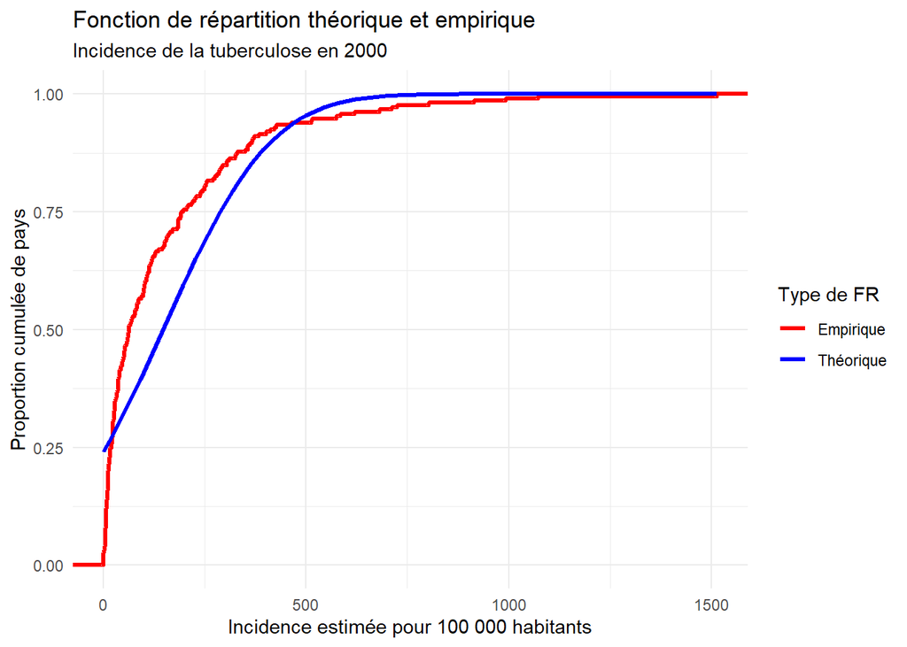

```r
TB2_2000%>% #data que pour l'année 2000

  ggplot()+  #initiation du graphique

  aes(# indique la correspondance entre les variables de notre tables et les esthétiques du graphique
    x = `Estimated_incidence_(all_forms)_per_100_000_population`) + #variable  placée en abscice

  stat_ecdf(#variable placée en ordonnée :  fonction de réparttion empirique
    geom = "step", #la courbe est en escalier
    aes(colour = "Empirique"), # on nomme cette courbe "empirique" dans la légende
    size = 1.2) + # épaisseur de la courbe

  stat_function( # permet d'ajouter  la courbe d'uen fonction mathématique
    fun = pnorm, # fonction mathématique que nous voulons tracer: focntion de répartition de la loi normale
    args = # paramètre de la focntion normale
      list(mean=mean(TB2_2000$`Estimated_incidence_(all_forms)_per_100_000_population`, # moyenne réel des données
                            na.rm = TRUE),# on ignore les valeurs manquantes s'il y en a
                sd=sd(TB2_2000$`Estimated_incidence_(all_forms)_per_100_000_population`,# écart type réel des donnés
                        na.rm = TRUE)),# on ignore les valeurs manquantes s'il y en a
      aes(colour = "Théorique"), # on nomme la courbe théorique dans la légende
      size = 1.2) + # épaisseur de la courbe

  labs(# labels : permet d'ajouter ou de modifier les titres et les étiques du graphique
    title = "Fonction de répartition théorique et empirique", #titre
    subtitle = "Incidence de la tuberculose en 2000", #sous titre
    x = "Incidence estimée pour 100 000 habitants",# nom afficher sur l'axe des abscisses
    y = "Proportion cumulée de pays", # nom affiché sur l'axe des ordonnés
    colour = "Type de FR" # nom afficher dans la légende pour distinguer empirique et théorique
  ) +

  scale_colour_manual(# personnalise manuellement les couleurs utilisées dans le graphique pour les courbes
    values = c("Empirique" = "red", # la courbe de la fonction de répartition empirique est rouge
                                 "Théorique" = "blue")) +# la courbe de la fonction de répartition théorique est bleu

  theme_minimal()# theme minimaliste  donc fond blanc et axes fins
```

Le graphique ci-dessus compare la fonction de répartition empirique de l’incidence de la tuberculose à la fonction de répartition théorique issue de la loi normale, ajustée avec la moyenne et l’écart-type des données observées.

On observe que la courbe empirique (rouge) s’écarte nettement de la courbe théorique (bleue) : Au début (pour les plus faibles valeurs d’incidence), la courbe empirique monte très rapidement, ce qui signifie qu’une grande proportion de pays a une incidence très faible (confirmant la concentration observée dans l’histogramme). Ensuite, la courbe empirique s’aplatit plus lentement que la courbe normale, indiquant que quelques pays ont des valeurs d’incidence très élevées, bien au-delà de ce que prévoirait une distribution normale.

Cette comparaison visuelle montre que la distribution de l’incidence ne suit pas la loi normale. Cela confirme ce qui a été observé dans l’histogramme : une distribution fortement asymétrique à droite, avec des données extrêmes qui rendent la loi normale inadaptée pour modéliser ces données sans transformation préalable.

## Calculs de coefficient d’asymétrie et d’aplatissement de l’incidence

```r
# `Estimated_incidence_(all_forms)_per_100_000_population

#calcul de coefficient d’asymétrie

x <- TB2%>% pull(# permet d'extraire une colone sous forme de vecteur numérique
  `Estimated_incidence_(all_forms)_per_100_000_population`)

y <- skewness(x,
              na.rm = TRUE)# on ignore les valeurs manquante s'il y en a

# Calcul du coefficient d'aplatissement

z<- kurtosis(x,
             na.rm = TRUE)# on ignore les valeurs manquante s'il y en a

print(paste("Le coefficient d'asymétrie de l'incidence est", y))
```

```
## [1] "Le coefficient d'asymétrie de l'incidence est 2.97380159034098"
```

```r
print(paste("Le coefficient d'applatissement est ", z))
```

```
## [1] "Le coefficient d'applatissement est  15.36896321823"
```

Le coefficient d’asymétrie de l’incidence est égal à 2,97, ce qui indique une distribution étalée vers la droite. Cela signifie que la majorité des pays ont une incidence relativement faible, tandis que quelques pays présentent des valeurs très élevées, ce qui allonge la queue de la distribution du côté des grandes valeurs. Cette observation est cohérente avec la définition du coefficient d’asymétrie, qui mesure le moment centré d’ordre 3 réduit : une valeur positive traduit une dissymétrie vers la droite.

Ces deux indicateurs numériques corroborent les résultats graphiques observés dans l’histogramme et la fonction de répartition : la variable “incidence de la tuberculose” présente une distribution non normale, avec une forte asymétrie à droite et une présence importante de valeurs extrêmes.

##boxplot par année pour tous les pays du monde de 1990 à 2013 pour l’incidence

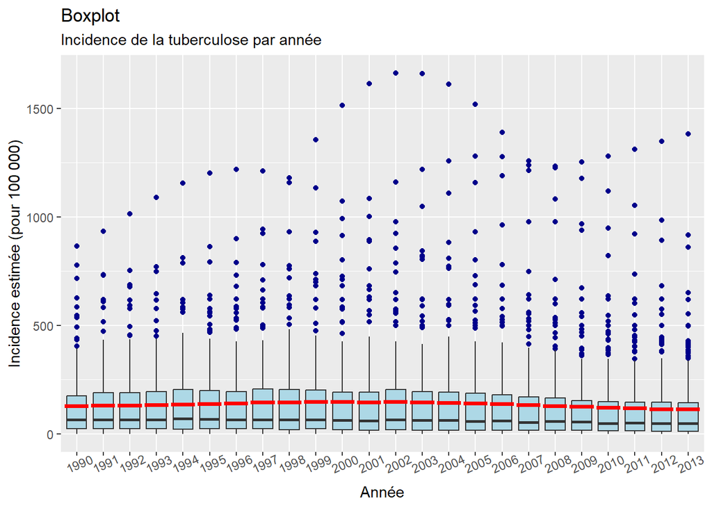

```r
TB2%>% # data de 1990 à 2013
  filter(!is.na(`Estimated_incidence_(all_forms)_per_100_000_population`)) %>% #on exclut les valeurs manquantes

  ggplot( #initialise le graphique
    aes(x = as.factor(Year), # abscice = année converti en facteur pour qu'un boxplot représente une année
        y = `Estimated_incidence_(all_forms)_per_100_000_population`)) + # ordonnée

  geom_boxplot( # géométrie du boxplot
    outlier.color = "darkblue", # les valeurs extrêmes sont représentées par des points en bleu
    fill = "lightblue") +#l'interieur des boîtes est rempli en bleu clair

  stat_summary(# ajoute un résumé statistique personnalisé en calculant une statistique
    fun = mean,# moyenne de l'incidence par année
    geom = "crossbar", # la moyenne est représentée par uen barre horizontale
    color = "red") + # cette barre est rouge

  labs(# labels : permet d'ajouter ou de modifier les titres et les étiques du graphique
    x = "Année", # nom abscisse
    y = "Incidence estimée (pour 100 000)", # nom ordonné
    title = "Boxplot", # titre
    subtitle = "Incidence de la tuberculose par année") +#sous titre

  theme(axis.text.x=element_text(angle=25))# les étiques des annnées sont incliné à 25°
```

Le boxplot représentant l’incidence estimée de la tuberculose (pour 100 000 habitants) sur la période 1990–2013 met en lumière une situation globalement stable mais très inégalitaire.

Entre 1990 et 2013, la médiane de l’incidence de la tuberculose reste stable, légèrement en dessous de 100 cas pour 100 000 habitants, ce qui reflète une situation inchangée pour la majorité des pays. En revanche, la moyenne, toujours supérieure à la médiane, met en évidence une asymétrie à droite persistante, due à quelques pays très touchés.

Les boîtes interquartiles étroites indiquent une forte concentration des pays autour de valeurs faibles, ce qui est cohérent avec le coefficient d’aplatissement élevé (15,37) : la distribution est resserrée mais marquée par la présence de valeurs très éloignées.

Pour conclure, le boxplot de l’année 2000 illustre visuellement une distribution non normale, avec une majorité de pays faiblement touchés et une minorité de pays fortement impactés. Il confirme toutes les analyses précédentes : une asymétrie à droite marquée, une distribution leptokurtique, et des disparités sanitaires profondes à l’échelle mondiale.

#I.1.2) Analyse univariée de la mortalité avec VIH ## Histogramme de la mortalité avec VIH

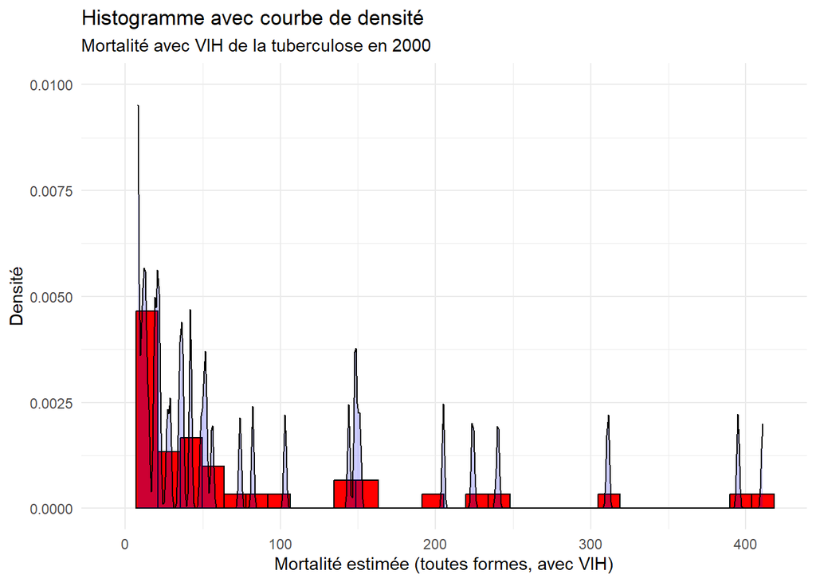

```r
TB2_2000 %>% #data que pour l'année 2000

  ggplot() + #initiation du graphique

  aes(# indique la correspondance entre les variables de notre tables et les esthétiques du graphique
    x = `Estimated_mortality_of_TB_cases_who_are_HIV-positive,_per_100_000_population`, #variable  placée en abscice
    y = after_stat(density)) +   # calcule automatiquement la densité pour l'ordonné

  geom_histogram( #géométrie de l'histogramme
    color = "black", # les contours de l'histogramme sont noirs
    fill = "red" ) +# les barres de l'histogramme sont remplis en  rouges

  geom_density(# géométrie de la densité
    alpha = 0.2,# transparence de la zone sous la courbe de densité
    fill = "blue") +   # la zone sous la coube de densité est bleu

  labs(# labels : permet d'ajouter ou de modifier les titres et les étiques du graphique
    title = "Histogramme avec courbe de densité", #titre
    subtitle = "Mortalité avec VIH de la tuberculose en 2000",  #sous titre
    x = "Mortalité estimée (toutes formes, avec VIH)", # nom affiché sur l'axe des abscisses
    y = "Densité") +#nom affiché sur l'axe des ordonnés

  ylim(0, 0.01) +   # Limiter l'échelle de densité entre 0 et 0.2


  theme_minimal() # theme minimaliste  donc fond blanc et axes fins
```

L’histogramme ci-dessous présente la distribution de la mortalité estimée de la tuberculose chez les personnes co-infectées par le VIH, exprimée en nombre de décès pour 100 000 habitants, pour l’année 2000.

La forme de la distribution observée met en évidence une forte asymétrie à droite. Une grande majorité de pays se concentrent dans les valeurs faibles de mortalité, avec un pic net entre 0 et 25. Cela suggère que, dans de nombreux pays, la co-infection tuberculose-VIH représente une cause de décès relativement marginale ou bien maîtrisée.

En revanche, on observe la présence de valeurs extrêmes très marquées, certains pays atteignant des niveaux supérieurs à 400 décès pour 100 000 habitants. Ces pays, minoritaires, concentrent une mortalité extrêmement élevée, ce qui reflète des contextes sanitaires particulièrement critiques, souvent en lien avec une forte prévalence du VIH, une couverture antirétroviral *(proportionde personnes vivant avec le VIH qui ont accès à un traitement antirétroviral)* insuffisant ou un accès limité aux soins de santé.

La courbe de densité superposée à l’histogramme montre une structure très irrégulière, avec une succession de pics étroits et localisés. Cette discontinuité suggère que la distribution n’est ni lisse ni continue, et pourrait refléter un nombre limité de pays concernés par une mortalité VIH-TB élevée, ou encore une déclaration groupée ou arrondie des données dans certaines zones géographiques.

Cet histogramme révèle une distribution très déséquilibrée, avec une majorité de pays faiblement touchés, mais également quelques pays confrontés à une mortalité extrêmement élevée. Cette configuration statistique met en évidence des inégalités sanitaires majeures, et souligne la nécessité d’approfondir l’analyse en fonction de variables explicatives telles que la prévalence du VIH, l’accès au traitement antirétroviral, ou encore les ressources du système de santé.

## Fonction de répartition de la mortalité avec VIH

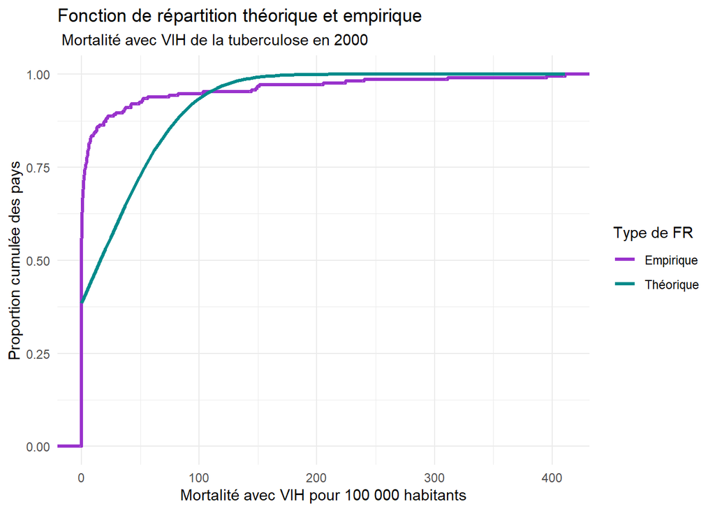

```r
TB2_2000%>% #data que pour l'année 2000

  ggplot()+ #initiation du graphique

  aes(# indique la correspondance entre les variables de notre tables et les esthétiques du graphique
    x = `Estimated_mortality_of_TB_cases_who_are_HIV-positive,_per_100_000_population`) + #variable  placée en abscice

  stat_ecdf( #variable placée en ordonnée :  fonction de réparttion empirique
    geom = "step", #la courbe est en escalier
    aes(colour = "Empirique"), # on nomme cette courbe "empirique" dans la légende
    size = 1.2) + #  épaisseur de la courbe

  stat_function(# permet d'ajouter  la courbe d'une fonction mathématique
    fun = pnorm,  #fonction mathématique que nous voulons tracer: focntion de répartition de la loi normale
    args = # paramètre de la fonction normale
      list(mean = mean(TB2_2000$`Estimated_mortality_of_TB_cases_who_are_HIV-positive,_per_100_000_population`, # moyenne réel des données
                       na.rm = TRUE),# on ignore les valeurs manquantes s'il y en a
           sd=sd(TB2_2000$`Estimated_mortality_of_TB_cases_who_are_HIV-positive,_per_100_000_population`# écart type réel des donnés
                  ,na.rm = TRUE)),# on ignore les valeurs manquantes s'il y en a
    aes(colour = "Théorique"), # on nomme la courbe théorique dans la légende
        size = 1.2) + # épaisseur de la courbe

   labs(# labels : permet d'ajouter ou de modifier les titres et les étiques du graphique
    title = "Fonction de répartition théorique et empirique", #titre
    subtitle=" Mortalité avec VIH de la tuberculose en 2000",#sous titre
    x = "Mortalité avec VIH pour 100 000 habitants",# nom afficher sur l'axe des abscisses
    y = "Proportion cumulée des pays",# nom affiché sur l'axe des ordonnés
    colour = "Type de FR"# nom afficher dans la légende pour distinguer empirique et théorique
  ) +

  scale_colour_manual(# personnalise manuellement les couleurs utilisées dans le graphique pour les courbes
    values = c("Empirique" = "darkorchid", # la courbe de la fonction de répartition empirique est violette
               "Théorique" = "darkcyan")) +# la courbe de la fonction de répartition théorique est bleu-vert

   theme_minimal()# theme minimaliste  donc fond blanc et axes fins
```

Le graphique présenté ci-après compare la fonction de répartition empirique de la mortalité estimée liée à la tuberculose chez les personnes vivant avec le VIH en 2000, à la fonction de répartition théorique issue de la loi normale, ajustée à partir de la moyenne et de l’écart-type des données observées.

En revanche, la courbe théorique (en bleu-vert), qui suit la forme d’une distribution normale, progresse de manière plus régulière et symétrique. Le décalage important entre les deux courbes met en évidence le fait que les données observées ne suivent pas une loi normale.

La courbe empirique s’aplatit lentement dans sa deuxième moitié, signalant la présence de valeurs extrêmes, c’est-à-dire quelques pays enregistrant une mortalité très élevée, bien au-delà de ce qu’un modèle normal permettrait de prévoir. Cette forme traduit une distribution asymétrique à droite, avec une queue allongée vers les fortes valeurs.

Ce constat est en cohérence avec l’analyse graphique précédente fondée sur l’histogramme. Il suggère également une forte hétérogénéité mondiale dans la gestion de la co-infection tuberculose-VIH. Tandis que la majorité des pays enregistrent une mortalité faible, quelques pays concentrent l’essentiel du fardeau, souvent situés dans des zones où le système de santé est fragilisé.

Sur le plan statistique, la distribution est clairement non normale, avec une asymétrie importante à droite et une distribution resserrée autour de faibles valeurs, mais avec des extrêmes fortement présents.

## Calculs des coefficients d’asymétrie et d’applatissement pour de la mortalité avec VIH

```r
#`Estimated_mortality_of_TB_cases_who_are_HIV-positive,_per_100_000_population`

#calcul de coefficient d’asymétrie

x <- TB2%>% pull(# permet d'extraire une colone sous forme de vecteur numérique
  `Estimated_mortality_of_TB_cases_who_are_HIV-positive,_per_100_000_population`)

y <- skewness(x,
              na.rm = TRUE)# on ignore les valeurs manquante s'il y en a

# Calcul du coefficient d'aplatissement

z <- kurtosis(x,
              na.rm = TRUE)# on ignore les valeurs manquante s'il y en a

print(paste("Le coefficient d'asymétrie de la mortalité avec VIH est", y))
```

```
## [1] "Le coefficient d'asymétrie de la mortalité avec VIH est 5.88239784140508"
```

```r
print(paste("Le coefficient d'applatissement de la mortalité avec VIH ", z))
```

```
## [1] "Le coefficient d'applatissement de la mortalité avec VIH  42.4407539708671"
```

Le coefficient d’asymétrie obtenu est de 5,88, ce qui indique une forte dissymétrie vers la droite. Une telle valeur, très supérieure à 0, confirme que la majorité des pays présentent une mortalité faible, tandis qu’un petit nombre de pays concentrent des valeurs très élevées, qui allongent la queue de la distribution du côté des grandes valeurs. Ce résultat est en parfaite cohérence avec l’histogramme et la fonction de répartition empirique, qui montraient déjà une montée rapide suivie d’un aplatissement lent.

Le coefficient d’aplatissement est quant à lui de 42,44, une valeur très largement supérieure à 3, seuil de référence pour une distribution normale. Cette valeur indique que la distribution resserrée, c’est-à-dire extrêmement concentrée autour de la médiane, mais avec la présence de nombreuses valeurs extrêmes très éloignées. Cela reflète une situation où la majorité des pays sont faiblement touchés, mais quelques-uns présentent une mortalité extrêmement élevée, ce qui accentue la dispersion globale.

## Boxplot par année pour tous les pays du monde de 1990 à 2013 pour la mortalité avec VIH

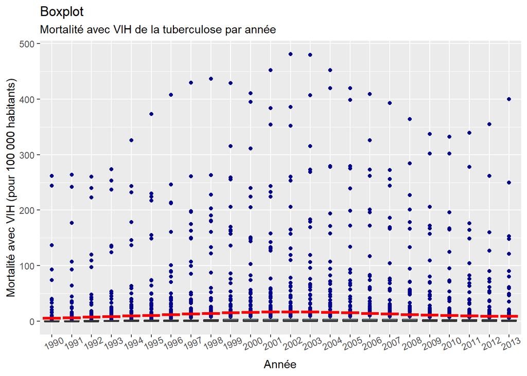

```r
TB2%>% # data de 1990 à 2013
  filter(!is.na(`Estimated_mortality_of_TB_cases_who_are_HIV-positive,_per_100_000_population`)) %>%#on exclut les valeurs manquantes
  ggplot(#initialise le graphique
    aes(
      x = as.factor(Year), # abscice = année converti en facteur pour qu'un boxplot représente une année
      y = `Estimated_mortality_of_TB_cases_who_are_HIV-positive,_per_100_000_population`)) + # ordonnée

   geom_boxplot(#géométrie du boxplot
    outlier.color = "darkblue", # les valeurs extrêmes sont représentées par des points en bleu
    fill = "lightblue") +#l'interieur des boîtes est rempli en bleu clair


  stat_summary(# ajoute un résumé statistique personnalisé en calculant une statistique
    fun = mean # moyenne de la mortalité avec VIH par année
    , geom = "crossbar",#la moyenne est représentée par uen barre horizontale
    color = "red") + # cette barre est rouge

  labs(# labels : permet d'ajouter ou de modifier les titres et les étiques du graphique
    x = "Année",  # nom abscisse
    y = "Mortalité avec VIH (pour 100 000 habitants)", # nom ordonnée
    title ="Boxplot",#titre
    subtitle= "Mortalité avec VIH de la tuberculose par année") + #sous titre

  theme(axis.text.x=element_text(angle=25))# les étiques des annnées sont incliné à 25°
```

Sur l’ensemble de la période 1990 à 2013, le boxplot permet de dégager plusieurs tendances temporelles et structurelles:

La médiane reste relativement stable et basse d’une année sur l’autre, ce qui confirme que dans la majorité des pays, la mortalité associée à la co-infection tuberculose-VIH demeure faible, malgré les fluctuations du contexte international. Toutefois, la moyenne (ligne rouge) reste nettement supérieure à la médiane chaque année, ce qui traduit une asymétrie persistante vers les fortes valeurs, causée par quelques pays concentrant des niveaux très élevés de mortalité.

La médiane reste située dans une zone très basse, ce qui confirme que la majorité des pays ont une mortalité faible (souvent inférieure à 25 décès pour 100 000 habitants). En revanche, on observe de très nombreux points atypiques (valeurs extrêmes), certains pays dépassant 400 décès pour 100 000 habitants, traduisant une situation sanitaire extrêmement critique dans quelques zones spécifiques.

Cette configuration est en cohérence avec l’histogramme, la fonction de répartition empirique, ainsi que les coefficients d’asymétrie (5,88) et d’aplatissement (42,44), qui confirment une distribution très asymétrique à droite et leptokurtique.

Le boxplot de l’année 2000 illustre ainsi une majorité de pays faiblement touchés, mais une minorité de pays fortement exposés, avec un niveau de mortalité particulièrement alarmant.

En définitive, l’analyse des boxplots sur la période 1990-2013 révèle que la mortalité tuberculose-VIH reste faible dans la majorité des pays, mais extrêmement élevée dans un groupe restreint de pays lourdement affectés. La situation de l’année 2000 illustre particulièrement bien ces inégalités, qui s’inscrivent dans une tendance globale stable mais très inégalitaire. Ces résultats justifient la nécessité de mener une analyse croisée avec des indicateurs socio-économiques et sanitaires (prévalence du VIH, couverture antirétrovirale, dépenses de santé) pour mieux comprendre les déterminants de ces écarts.

#I.1.3) Analyse univariée de la mortalité sans VIH ## Histogramme de la mortalité sans VIH

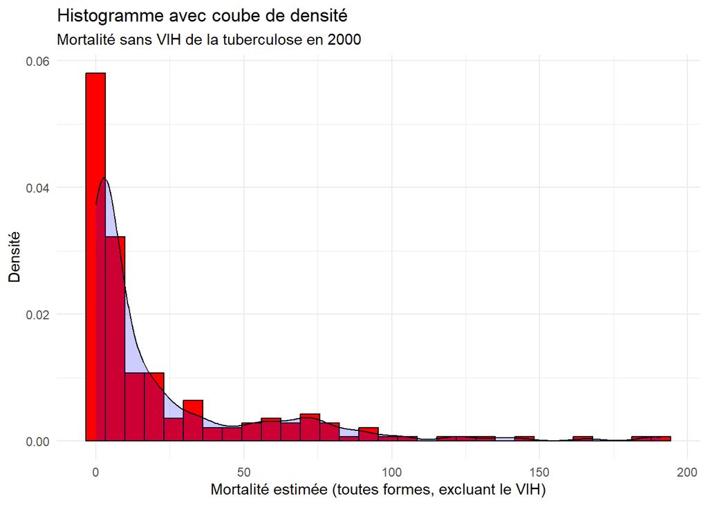

```r
#"Estimated_mortality_of_TB_cases_(all_forms,_excluding_HIV)_per_100_000_population"

TB2_2000 %>% #data que pour l'année 2000

  ggplot() +#initiation du graphique

  aes(# indique la correspondance entre les variables de notre tables et les esthétiques du graphique
    x = `Estimated_mortality_of_TB_cases_(all_forms,_excluding_HIV)_per_100_000_population`, #variable  placée en abscice
    y = after_stat(density)) +  # calcule automatiquement la densité pour l'ordonné

  geom_histogram( #géométrie de l'histogramme
    color = "black", # les contours de l'histogramme sont noirs
    fill = "red") +  # les barres de l'histogramme sont remplis en  rouges

  geom_density(# géométrie de la densité
    alpha = 0.2, # transparence de la zone sous la courbe de densité
    fill = "blue") +  # la zone sous la coube de densité est bleu

  labs(# labels : permet d'ajouter ou de modifier les titres et les étiques du graphique
    title = "Histogramme avec coube de densité", #titre
    subtitle="Mortalité sans VIH de la tuberculose en 2000",  #sous titre
    x = "Mortalité estimée (toutes formes, excluant le VIH)", # nom affiché sur l'axe des abscisses
    y = "Densité") + #nom   affiché sue l'axe des ordonnées

  theme_minimal()# theme minimaliste  donc fond blanc et axes fins
```

Le graphique ci-dessus représente la distribution de la mortalité due à la tuberculose (toutes formes, excluant les cas associés au VIH) pour l’année 2000, exprimée en nombre de décès pour 100 000 habitants. Cette représentation combine un histogramme (en rouge) et une courbe de densité (en bleu), permettant une lecture précise de la répartition des pays selon leur niveau de mortalité.

La distribution est très asymétrique à droite, avec une forte concentration de pays présentant une mortalité faible ou très faible. Le pic principal de densité se situe entre 0 et 10 décès pour 100 000 habitants, ce qui indique que la majorité des pays enregistrent une mortalité relativement faible lorsqu’on exclut les cas liés au VIH.

Au-delà de 25 décès, la fréquence des pays diminue nettement. Toutefois, on observe encore quelques pays avec des niveaux supérieurs à 100, voire jusqu’à près de 200 décès pour 100 000 habitants, signalant l’existence de valeurs extrêmes, mais moins nombreuses et moins élevées que dans le cas de la mortalité liée à la co-infection VIH-Tuberculose.

Comparée à la distribution de la mortalité avec VIH, la forme ici est plus resserrée : la queue droite est moins étalée, et les valeurs extrêmes sont moins fréquentes et moins éloignées. Cela suggère que la co-infection avec le VIH joue un rôle amplificateur important dans l’élévation des niveaux de mortalité, ce que confirment d’ailleurs les analyses précédentes.

En somme, la distribution de la mortalité tuberculose (hors VIH) en 2000 reste asymétrique et non normale, mais apparaît moins marquée dans ses extrêmes que celle incluant les cas liés au VIH. Cette observation met en évidence l’impact significatif du VIH sur la gravité de la tuberculose dans certains pays, et souligne l’intérêt d’une analyse comparative entre les deux indicateurs pour mieux cerner le rôle du VIH dans la dynamique de la mortalité tuberculeuse

## Fonction de répartition de la mortalité sans VIH

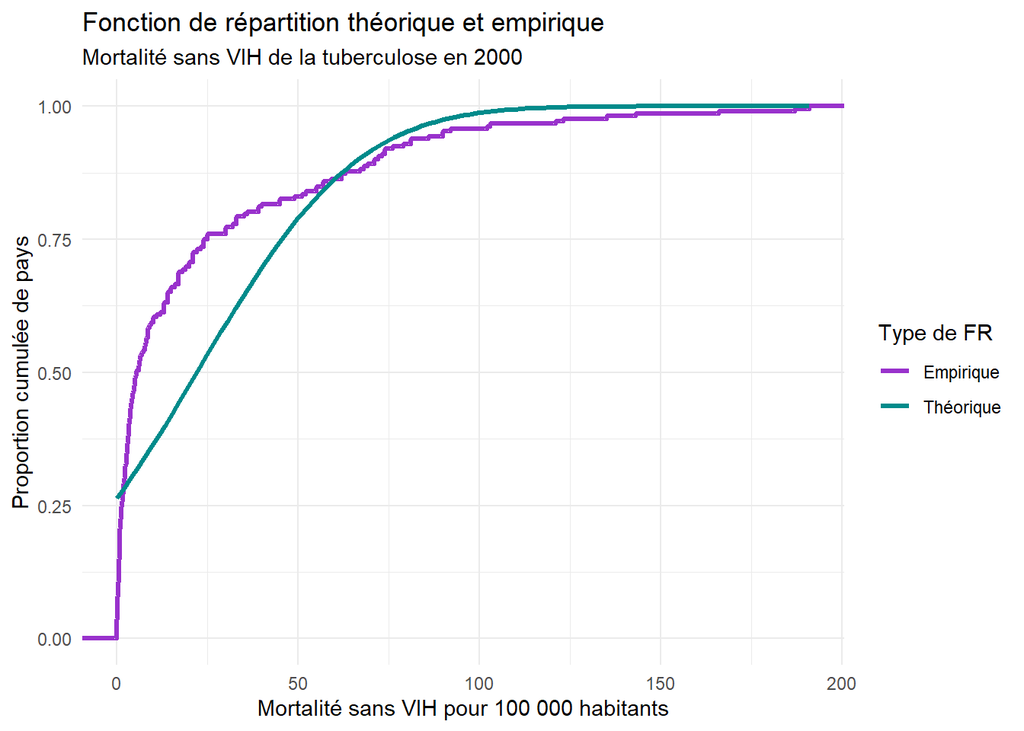

```r
TB2_2000%>% #data que pour l'année 2000

  ggplot()+ #initiation du graphique

  aes(# indique la correspondance entre les variables de notre tables et les esthétiques du graphique
    x = `Estimated_mortality_of_TB_cases_(all_forms,_excluding_HIV)_per_100_000_population`) +  #variable  placée en abscice

  stat_ecdf(#variable placée en ordonnée :  fonction de réparttion empirique
    geom = "step", #la courbe est en escalier
    aes(colour = "Empirique"), # on nomme cette courbe "empirique" dans la légende
    size = 1.2) + #  épaisseur de la courbe

  stat_function(# permet d'ajouter  la courbe d'une fonction mathématique
    fun = pnorm, #fonction mathématique que nous voulons tracer: focntion de répartition de la loi normale
    args = # paramètre de la fonction normale
      list(mean = mean(TB2_2000$`Estimated_mortality_of_TB_cases_(all_forms,_excluding_HIV)_per_100_000_population`, # moyenne réel des données
                       na.rm = TRUE),# on ignore les valeurs manquantes s'il y en a
           sd = sd(TB2_2000$`Estimated_mortality_of_TB_cases_(all_forms,_excluding_HIV)_per_100_000_population`,# écart type réel des donnés
                    na.rm = TRUE)),# on ignore les valeurs manquantes s'il y en a
    aes(colour = "Théorique"), # on nomme cette courbe "théorique" dans la légende
        size = 1.2) +  #  épaisseur de la courbe

   labs( # labels : permet d'ajouter ou de modifier les titres et les étiques du graphique
    title = "Fonction de répartition théorique et empirique",
    subtitle =  "Mortalité sans VIH de la tuberculose en 2000",
    x = "Mortalité sans VIH pour 100 000 habitants",# nom afficher sur l'axe des abscisses
    y = "Proportion cumulée de pays",# nom afficher sur l'axe des ordonnées
    colour = "Type de FR" # nom afficher dans la légende pour distinguer empirique et théorique
  ) +

  scale_colour_manual(# personnalise manuellement les couleurs utilisées dans le graphique pour les courbes
    values = c("Empirique" = "darkorchid",  # la courbe de la fonction de répartition empirique est violette
               "Théorique" = "darkcyan")) +# la courbe de la fonction de répartition théorique est bleu-vert

  theme_minimal() # theme minimaliste  donc fond blanc et axes fins
```

Le graphique ci-dessus compare la fonction de répartition empirique (en violet) de la mortalité estimée liée à la tuberculose (hors cas liés au VIH) en 2000, à la fonction de répartition théorique (en bleu-vert) correspondant à une distribution normale ajustée à partir des données observées.

La fonction empirique croît de manière abrupte dès les premières valeurs, ce qui montre qu’une proportion très élevée de pays présente une mortalité relativement faible. En effet, plus de 75 % des pays ont une mortalité inférieure à environ 50 décès pour 100 000 habitants, ce qui confirme la concentration des données autour de faibles valeurs, déjà observée dans l’histogramme.

En comparaison, la fonction théorique, issue d’une loi normale, progresse plus lentement et de manière symétrique. Cette différence indique que la distribution réelle des données n’est pas conforme à la loi normale. La courbe empirique s’éloigne nettement de la théorique dans les premières valeurs, signe que la distribution est asymétrique à droite.

À partir d’environ 100 décès pour 100 000 habitants, les deux courbes tendent à se rapprocher, suggérant que les valeurs extrêmes sont peu nombreuses, mais que leur influence reste visible dans la distribution globale. Cela traduit une présence limitée mais réelle de pays fortement touchés, même en l’absence du VIH.

En somme, cette fonction de répartition met en évidence une concentration importante de pays avec une mortalité faible et une asymétrie vers les fortes valeurs, bien que moins marquée que dans la distribution incluant le VIH. L’écart observé entre la courbe empirique et la fonction normale souligne une non-normalité des données, ce qui appelle à une prudence dans l’interprétation statistique et renforce l’intérêt d’une analyse différenciée entre mortalité avec et sans VIH.

## Calculs des coefficients d’asymétrie et d’applatissement de la mortalité sans VIH

```r
#"Estimated_mortality_of_TB_cases_(all_forms,_excluding_HIV)_per_100_000_population"

#calcul de coefficient d’asymétrie

x <- TB2%>% pull(# permet d'extraire une colone sous forme de vecteur numérique
  `Estimated_mortality_of_TB_cases_(all_forms,_excluding_HIV)_per_100_000_population`)


y <- skewness(x,
              na.rm = TRUE) # on ignore les valeurs manquante s'il y en a

# Calcul du coefficient d'aplatissement
z<- kurtosis(x,
             na.rm = TRUE)# on ignore les valeurs manquante s'il y en a

print(paste("Le coefficient d'asymétrie de la mortalité sans VIH est", y))
```

```
## [1] "Le coefficient d'asymétrie de la mortalité sans VIH est 2.87853978686326"
```

```r
print(paste("Le coefficient d'applatissement de la mortalité sans VIH est ", z))
```

```
## [1] "Le coefficient d'applatissement de la mortalité sans VIH est  14.2887100177968"
```

Le coefficient d’asymétrie (skewness) est de 2,88, ce qui indique une distribution asymétrique à droite. Autrement dit, la majorité des pays présentent des niveaux de mortalité relativement faibles, mais quelques pays affichent des valeurs nettement plus élevées, ce qui allonge la queue droite de la distribution. Bien que ce niveau d’asymétrie soit important, il reste moins extrême que celui observé pour la mortalité avec VIH (où l’asymétrie était de 5,88).

Le coefficient d’aplatissement (kurtosis) atteint 14,29, valeur largement supérieure au seuil de référence de 3 (distribution normale). Cela indique une distribution caractérisée par une forte concentration des valeurs autour de la médiane, mais aussi par la présence de valeurs extrêmes éloignées, bien que peu nombreuses. Cette observation est cohérente avec les graphiques précédents (histogramme et fonction de répartition), qui montraient un pic de densité très net et quelques cas isolés de forte mortalité.

En définitive, ces deux coefficients confirment que la distribution de la mortalité tuberculose sans VIH en 2000 est non normale, asymétrique à droite et très resserrée, avec quelques pays concentrant des valeurs anormalement élevées. De plus, comparée à la mortalité incluant le VIH, cette distribution est moins extrême, ce qui suggère que la co-infection avec le VIH aggrave considérablement la mortalité liée à la tuberculose dans certains contextes. Ces constats soulignent l’importance de différencier les analyses selon le statut VIH afin de mieux cibler les réponses sanitaires.

## Boxplot par année pour tous les pays du monde de 1990 à 2013 pour la mortalité sans VIH

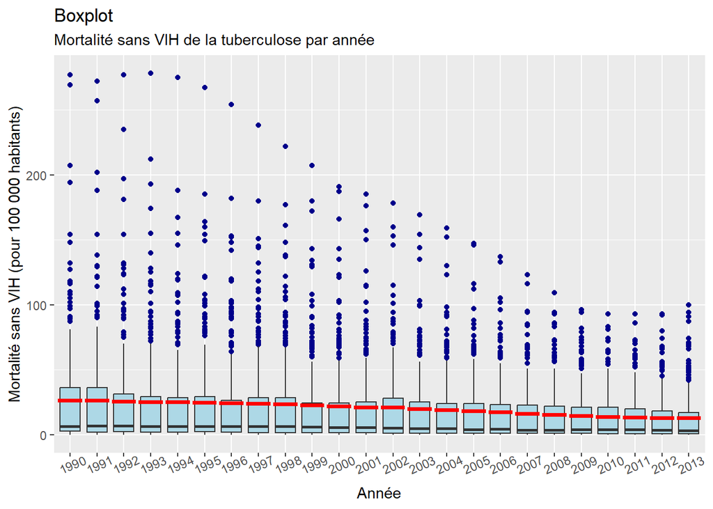

```r
TB2%>% # data de 1990 à 2013
  filter(!is.na(`Estimated_mortality_of_TB_cases_(all_forms,_excluding_HIV)_per_100_000_population`)) %>%#on exclut les valeurs manquantes

  ggplot( #initialise le graphique
    aes(
      x = as.factor(Year), # abscice = année converti en facteur pour qu'un boxplot représente une année
      y = `Estimated_mortality_of_TB_cases_(all_forms,_excluding_HIV)_per_100_000_population`)) + # ordonnée

  geom_boxplot(# géométrie du boxplot
    outlier.color = "darkblue", # les valeurs extrêmes sont représentées par des points en bleu
    fill = "lightblue") +#l'interieur des boîtes est rempli en bleu clair

  stat_summary(# ajoute un résumé statistique personnalisé en calculant une statistique
    fun = mean,# moyenne de la mortalité sans VIH par année
    geom = "crossbar", # la moyenne est représentée par uen barre horizontale
    color = "red") + # cette barre est rouge


  labs(# labels : permet d'ajouter ou de modifier les titres et les étiques du graphique
    x = "Année", # nom abscisse
    y = "Mortalité sans VIH (pour 100 000 habitants)", # nom ordonné
    title ="Boxplot", # titre
    subtitle ="Mortalité sans VIH de la tuberculose par année") + #sous titre

  theme(axis.text.x=element_text(angle=25)) # les étiques des annnées sont inclinées à 25°
```

Le boxplot ci-dessus permet de visualiser l’évolution de la mortalité estimée liée à la tuberculose (hors co-infection VIH) dans le monde, de 1990 à 2013.

Dans l’ensemble, on observe une tendance générale à la baisse : la médiane diminue progressivement au fil des années, tout comme la moyenne (ligne rouge), traduisant une amélioration globale de la prise en charge et du contrôle de la tuberculose au niveau international.

La médiane reste toujours nettement inférieure à la moyenne, ce qui reflète une distribution asymétrique à droite persistante : la plupart des pays affichent des niveaux relativement faibles de mortalité, mais un petit nombre de pays présente des valeurs très élevées, tirant la moyenne vers le haut.

Cette asymétrie est particulièrement marquée jusqu’au début des années 2000, où l’on observe un grand nombre de valeurs extrêmes. Certains pays dépassent régulièrement les 200 décès pour 100 000 habitants, témoignant de disparités sanitaires marquées entre pays.

À partir de 2005, on remarque une réduction notable du nombre de valeurs extrêmes, bien que celles-ci ne disparaissent pas totalement. Cette évolution positive peut être liée à une amélioration progressive des systèmes de santé et des programmes de lutte contre la tuberculose dans certaines régions du monde.

L’année 2000 se situe à un moment charnière de la période analysée, et son boxplot permet d’illustrer clairement les inégalités mondiales en matière de mortalité liée à la tuberculose hors VIH.

Cette configuration est cohérente avec les résultats des coefficients d’asymétrie (2,88) et d’aplatissement (14,29) observés pour cette même année. Ces valeurs indiquent une distribution fortement asymétrique à droite, avec une forte concentration autour de valeurs faibles, mais accompagnée de valeurs extrêmes très élevées.

Pour conclure, entre 1990 et 2013, la mortalité liée à la tuberculose (hors VIH) tend globalement à diminuer, mais les inégalités entre pays restent marquées, comme l’illustre parfaitement l’année 2000. Ce constat appelle à approfondir l’analyse avec des variables explicatives telles que le niveau de revenu, l’accès aux soins ou encore la couverture vaccinale, pour mieux comprendre les déterminants de cette hétérogénéité mondiale

#I.1.4) Analyse univariée de la prévalence ## Histogramme de la prévalence

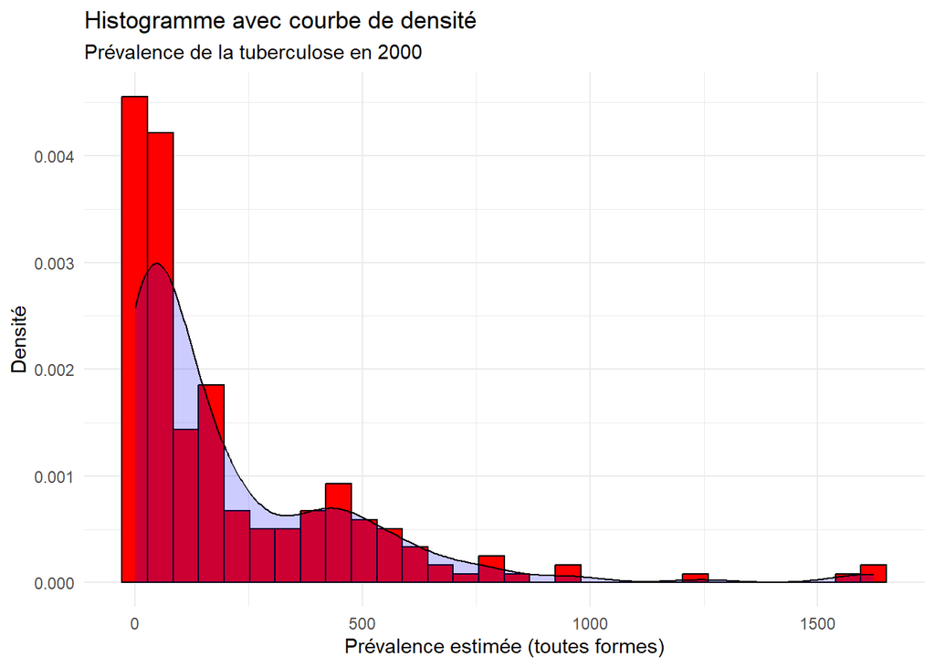

```r
#"Estimated_prevalence_of_TB_(all_forms)_per_100_000_population"

TB2_2000 %>% #data que pour l'année 2000

  ggplot() + #initiation du graphique

  aes(   # indique la correspondance entre les variables de notre tables et les esthétiques du graphique
    x = `Estimated_prevalence_of_TB_(all_forms)_per_100_000_population`,#variable  placée en abscice
    y = after_stat(density)) +  # calcule automatiquement la densité pour l'ordonné

   geom_histogram(#géométrie de l'histogramme
    color = "black",  # les contours de l'histogramme sont noirs
    fill = "red") + # les barres de l'histogramme sont remplis en  rouges

  geom_density( # géométrie de la densité
    alpha = 0.2, # transparence de la zone sous la courbe de densité
    fill = "blue") +   # la zone sous la coube de densité est bleu

  labs( # labels : permet d'ajouter ou de modifier les titres et les étiques du graphique
    title = "Histogramme avec courbe de densité", #titre
    subtitle = "Prévalence de la tuberculose en 2000", #sous titre
    x = "Prévalence estimée (toutes formes)", # nom abscisse
    y = "Densité") + #nom ordonné

  theme_minimal() # theme minimaliste  donc fond blanc et axes fins
```

L’histogramme ci-dessus représente la distribution de la prévalence estimée de la tuberculose (exprimée pour 100 000 habitants) pour l’année 2000, accompagné d’une courbe de densité permettant de mieux visualiser la forme de la distribution.

La distribution est nettement asymétrique à droite : la grande majorité des pays présentent une prévalence faible, concentrée dans les premières classes de l’histogramme (entre 0 et 100 cas pour 100 000 habitants). Cela se confirme visuellement par un pic de densité élevé dans cette zone.

Au-delà de 300 cas pour 100 000 habitants, la densité diminue fortement, bien que l’on observe encore quelques valeurs extrêmes s’élevant jusqu’à plus de 1500 cas, ce qui témoigne de disparités sanitaires très marquées à l’échelle mondiale.

La courbe de densité bleue suit de près la forme de l’histogramme, avec un pic étroit et prononcé à gauche, suivi d’une longue queue qui s’étale vers la droite. Cela traduit une distribution resserée et concentrée autour des faibles valeurs mais accompagnée de pays fortement touchés, dont les valeurs extrêmes influencent la structure globale.

Cette forme traduit également une non-normalité de la variable : l’écart entre les faibles valeurs fréquentes et les fortes valeurs rares est trop important pour qu’un modèle normal soit adapté sans transformation.

Ce graphique met en évidence une inégalité marquée dans la répartition mondiale de la tuberculose en 2000. Alors que de nombreux pays (souvent à revenu élevé ou disposant de systèmes de santé efficaces) affichent une prévalence relativement maîtrisée, d’autres (principalement dans les régions à faibles ressources ou en contexte de crise) concentrent des niveaux de prévalence très préoccupants.

##Fonction de répartition de la prévalence

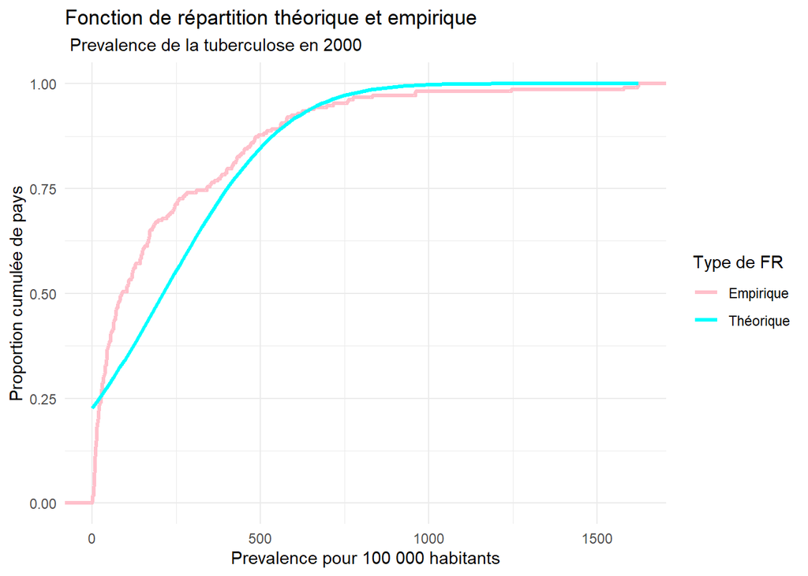

```r
TB2_2000%>% #data que pour l'année 2000

  ggplot()+ #initiation du graphique

  aes(# indique la correspondance entre les variables de notre tables et les esthétiques du graphique
    x = `Estimated_prevalence_of_TB_(all_forms)_per_100_000_population`) +  #variable  placée en abscice

  stat_ecdf(#variable placée en ordonnée :  fonction de réparttion empirique
    geom = "step",  #la courbe est en escalier
    aes(colour = "Empirique"), # on nomme cette courbe "empirique" dans la légende
    size = 1.2) + #  épaisseur de la courbe

  stat_function(# permet d'ajouter  la courbe d'une fonction mathématique
    fun = pnorm,  #fonction mathématique que nous voulons tracer: focntion de répartition de la loi normale
    args = # paramètre de la fonction normale
      list(mean = mean(TB2_2000$`Estimated_prevalence_of_TB_(all_forms)_per_100_000_population`, # moyenne réel des données
                       na.rm = TRUE), # on ignore les valeurs manquantes s'il y en a
            sd = sd(TB2_2000$`Estimated_prevalence_of_TB_(all_forms)_per_100_000_population`, # écart type réel des donnés
                    na.rm = TRUE)),# on ignore les valeurs manquantes s'il y en a
      aes(colour = "Théorique"), # on nomme cette courbe "théorique" dans la légende
      size = 1.2) + #  épaisseur de la courbe

  labs(# labels : permet d'ajouter ou de modifier les titres et les étiques du graphique
    title = "Fonction de répartition théorique et empirique", # titre
    subtitle = " Prevalence de la tuberculose en 2000",#sous titre
    x = "Prevalence pour 100 000 habitants", # nom afficher sur l'axe des abscisses
    y = "Proportion cumulée de pays",# nom afficher sur l'axe des ordonnées
    colour = "Type de FR"# nom afficher dans la légende pour distinguer empirique et théorique
  ) +

  scale_colour_manual(# personnalise manuellement les couleurs utilisées dans le graphique pour les courbes
    values = c("Empirique" = "pink",  # la courbe de la fonction de répartition empirique est rose
               "Théorique" = "cyan")) +# la courbe de la fonction de répartition théorique est cyan

  theme_minimal() # theme minimaliste  donc fond blanc et axes fins
```

Le graphique ci-dessus compare la fonction de répartition empirique (en rose) de la prévalence estimée de la tuberculose en 2000 à la fonction de répartition théorique (en cyan) correspondant à une loi normale ajustée à partir de la moyenne et de l’écart-type des données observées.

Cete analyse met en évidence une dynamique de distribution particulièrement déséquilibrée entre les pays.

Cependant, à partir d’un certain seuil, la progression de la courbe ralentit fortement, traduisant l’existence d’un petit groupe de pays affichant une prévalence très élevée, parfois au-delà de 1 000 cas pour 100 000 habitants. Cette configuration illustre une distribution fortement asymétrique à droite, caractérisée par une majorité de pays faiblement touchés, et une minorité concentrant les niveaux les plus alarmants.

En parallèle, la courbe théorique (en cyan), qui repose sur une hypothèse de normalité ajustée à partir de la moyenne et de l’écart-type des données, affiche une montée plus régulière et symétrique. Elle ne parvient donc pas à reproduire la dynamique observée dans les données empiriques, ce qui souligne une inadaptation du modèle normal pour décrire fidèlement la réalité statistique.

L’écart entre les deux courbes s’explique par plusieurs facteurs structurels : l’asymétrie marqué de la distribution vers les grandes valeurs, la forte concentration des pays dans les faibles niveaux de prévalence et la présence de valeurs extrêmes qui allongent significativement la queue de distribution.

Ces disparités reflètent des inégalités sanitaires mondiales profondes. Tandis que certains pays parviennent à contenir la tuberculose grâce à des systèmes de santé performants, d’autres , souvent à faibles ressources, continuent de faire face à une prévalence élevée, en raison de l’accès limité au diagnostic, à la prévention et aux traitements efficaces.

En définitve,La fonction de répartition empirique révèle une forte hétérogénéité mondiale dans la prévalence de la tuberculose en 2000. La loi normale, bien qu’utilisée comme référence, ne permet pas de rendre compte fidèlement de la réalité des données, qui sont marquées par une asymétrie droite et la présence de valeurs extêmes.

##Calculs des coefficients d’asymétrie et d’aplatissement

```r
# "Estimated_prevalence_of_TB_(all_forms)_per_100_000_population"

#calcul de coefficient d’asymétrie

x <- TB2%>%
  pull(# permet d'extraire une colone sous forme de vecteur numérique
    `Estimated_prevalence_of_TB_(all_forms)_per_100_000_population`)

# donc x contient uniquement les valeurs numérques de la colonne concernée

y<- skewness(x,
             na.rm = TRUE) #on ignore les valeurs manquantes s'il y en a

# Calcul du coefficient d'aplatissement

z<- kurtosis(x,
             na.rm = TRUE)#on ignore les valeurs manquantes s'il y en a

print(paste("Le coefficient d'asymétrie de la prévalence est", y))
```

```
## [1] "Le coefficient d'asymétrie de la prévalence est 2.42257283826437"
```

```r
print(paste("Le coefficient d'applatissement de la prévalence est ", z))
```

```
## [1] "Le coefficient d'applatissement de la prévalence est  10.8367641254459"
```

Le coefficient d’asymétrie (aussi appelé skewness) est positif et élevé (2,42), ce qui indique que la distribution est étalée vers les grandes valeurs. Autrement dit, la majorité des pays ont une prévalence faible, tandis que quelques pays présentent des niveaux exceptionnellement élevés, tirant la queue de la distribution vers la droite. Ce résultat est cohérent avec ce qui a été observé sur les graphiques (histogramme, courbe de densité et fonction de répartition), où la courbe empirique s’élève rapidement puis s’aplatit lentement.

Le coefficient d’aplatissement (ou kurtosis) est de 10,84, soit très supérieur à la valeur de référence de 3 pour une loi normale. Cela signifie que la distribution présente une forte concentration des données autour de la médiane ainsi qu’une présence non négligeable de valeurs extrêmes, éloignées du centre. Autrement dit, la plupart des pays ont une prévalence très proche de la médiane, mais une minorité de pays dérogent fortement à cette tendance, avec des niveaux de prévalence très élevés.

## Boxplot par année pour tous les pays du monde de 1990 à 2013 pour la prévalence

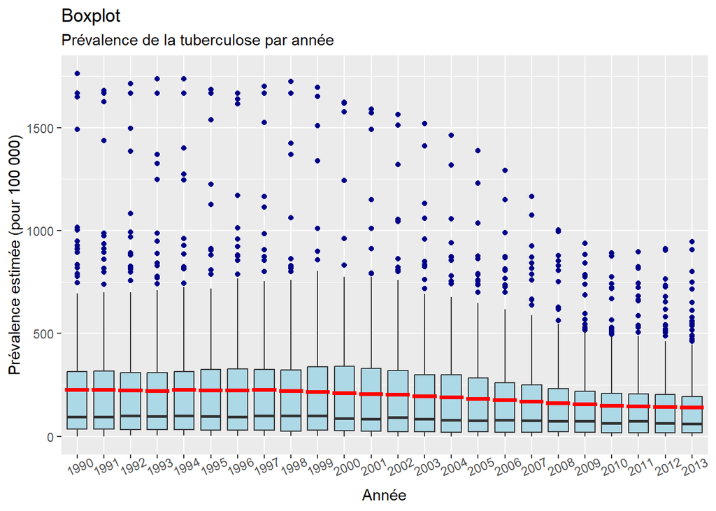

```r
TB2%>%# data de 1990 à 2013
  filter(!is.na(`Estimated_prevalence_of_TB_(all_forms)_per_100_000_population`)) %>%#on exclut les valeurs manquantes

  ggplot(#initialise le graphique
    aes(
      x = as.factor(Year), # abscice = année converti en facteur pour qu'un boxplot représente une année
      y = `Estimated_prevalence_of_TB_(all_forms)_per_100_000_population`)) +# ordonnée

  geom_boxplot( # géométrie du boxplot
    outlier.color = "darkblue", # les valeurs extrêmes sont représentées par des points en bleu
    fill = "lightblue") + #l'interieur des boîtes est rempli en bleu clair

  stat_summary(# ajoute un résumé statistique personnalisé en calculant une statistique
    fun = mean, # moyenne de la mortalité sans VIH par année
    geom = "crossbar", # la moyenne est représentée par uen barre horizontale
    color = "red") + # cette barre est rouge

  labs(# labels : permet d'ajouter ou de modifier les titres et les étiques du graphique
    x = "Année", # nom abscisse
    y = "Prévalence estimée (pour 100 000)", # nom ordonné
    title = "Boxplot", # titre
    subtitle = "Prévalence de la tuberculose par année") +#sous titre

  theme(axis.text.x=element_text(angle=25)) # les étiques des annnées sont inclinées à 25°
```

Le graphique ci-dessus présente l’évolution de la prévalence estimée de la tuberculose (pour 100 000 habitants) à l’échelle mondiale entre 1990 et 2013. Ce boxplot temporel permet de dégager plusieurs tendances structurelles et dynamiques marquantes au fil des années.

Cependant, on remarque que la moyenne (ligne rouge) est systématiquement située au-dessus de la médiane, ce qui reflète une asymétrie à droite persistante dans la distribution. Cette configuration indique que quelques pays fortement touchés par la tuberculose tirent la moyenne vers le haut, sans affecter les valeurs centrales de la majorité des pays.

À partir de 2006,plusieurs signaux positifs apparaissent. On observe une légère diminution de la moyenne,une réduction de l’intervalle interquartile (la boîte devient plus petite) et une diminution du nombre de valeurs extrêmes, bien que celles-ci restent présentes. Ces éléments suggèrent une amélioration progressive de la situation dans les pays les plus affectés, sans pour autant résorber totalement les disparités.

Cette structure en boîte allongée vers le haut avec une forte concentration autour de valeurs faibles traduit une distribution asymétrique à droite et resserrée. Cela confirme une forte concentration des pays autour de niveaux faibles, avec une minorité en situation critique. Cette inégalité structurelle est probablement liée à des facteurs systémiques : pauvreté, sous-financement des systèmes de santé, faible couverture vaccinale ou accès limité au traitement.

Afin d’illustrer plus concrètement cette dynamique globale, il est pertinent de s’arrêter sur l’année 2000, qui constitue un point central dans la série et reflète avec acuité la répartition inégalitaire de la prévalence de la tuberculose.

Le boxplot centré sur l’année 2000 met en évidence une forte hétérogénéité de la prévalence de la tuberculose à l’échelle mondiale. Il révèle des disparités notables entre les pays, tant en termes de niveaux moyens que d’écarts extrêmes.

Le boxplot montre également de longues moustaches supérieures et une multiplicité de points atypiques dépassant largement les 1000 voire 1500 cas pour 100 000 habitants. Ces valeurs extrêmes traduisent une distribution étalée vers la droite, caractéristique d’un phénomène où les cas extrêmes jouent un rôle central.

En définitive, Le boxplot de l’année 2000 illustre avec force les inégalités sanitaires mondiales en matière de tuberculose. Il révèle une majorité de pays modérément touchés, une moyenne élevée influencée par des extrêmes et ne dispersion importante liée à des crises sanitaires localisées. Ces constats rejoignent ceux établis sur l’ensemble de la période 1990–2013 : des disparités structurelles fortes qui justifient une analyse croisée avec des indicateurs socio-économiques et sanitaires (revenu par habitant, dépenses de santé, accès aux soins, charge du VIH, etc.), afin de mieux comprendre les déterminants de ces écarts et orienter les politiques de santé publique.

#I.B) Analyse univariée des variables qualitatives

#I.1.1) Prévalence ## Test quantiles et écarts interquantiles sur la prévalence

```r
#pour verifier et savoir les differents quantiles et demander pourquoi on a 100 et 90

quantile(TB2$`Estimated_prevalence_of_TB_(all_forms)_per_100_000_population`,
         probs = seq(0, 1, by = 0.1), na.rm = TRUE)
```

```
##   0%  10%  20%  30%  40%  50%  60%  70%  80%  90% 100%
##    0    9   17   31   53   85  132  219  346  525 1762
```

#quantiles et ecarts interquantiles ##estimated prev

```r
# Calcul des quantiles pour la variable 'Estimated_prevalence_of_TB_(all_forms)_per_100_000_population'
quantiles_prev <- quantile(TB2$`Estimated_prevalence_of_TB_(all_forms)_per_100_000_population`,
                      probs = c(0.25, 0.5, 0.75), na.rm = TRUE)

# Calcul de l'écart interquartile (IQR)
iqr_prev <- IQR(TB2$`Estimated_prevalence_of_TB_(all_forms)_per_100_000_population`, na.rm = TRUE)

# Afficher les résultats
quantiles_prev
```

```
## 25% 50% 75%
##  23  85 272
```

```r
iqr_prev
```

```
## [1] 249
```

# Tableau de fréquence prévalence

```r
qual_prev<-TB2_2000 %>%
  select(prevalence) %>%st(out = "return")
qual_prev
```

```
##      Variable   N Percent
## 1  prevalence 212
## 2       ... 1  21     10%
## 3       ... 2  21     10%
## 4       ... 3  19      9%
## 5       ... 4  21     10%
## 6       ... 5  23     11%
## 7       ... 6  16      8%
## 8       ... 7  23     11%
## 9       ... 8  16      8%
## 10      ... 9  28     13%
## 11     ... 10  24     11%
```

```r
as.data.frame(qual_prev) %>%
  kableExtra::kable("html", caption = "📊 Tableau 1 – Statistiques de la variable prévalence année 2000") %>%
  kableExtra::kable_styling(full_width = FALSE, bootstrap_options = c("striped", "hover"))
```

📊 Tableau 1 – Statistiques de la variable prévalence année 2000

| Variable | N | Percent |
| --- | --- | --- |
| prevalence | 212 |  |
| … 1 | 21 | 10% |
| … 2 | 21 | 10% |
| … 3 | 19 | 9% |
| … 4 | 21 | 10% |
| … 5 | 23 | 11% |
| … 6 | 16 | 8% |
| … 7 | 23 | 11% |
| … 8 | 16 | 8% |
| … 9 | 28 | 13% |
| … 10 | 24 | 11% |

## Diagrame en barre (pour prevalence avec pourcentage)

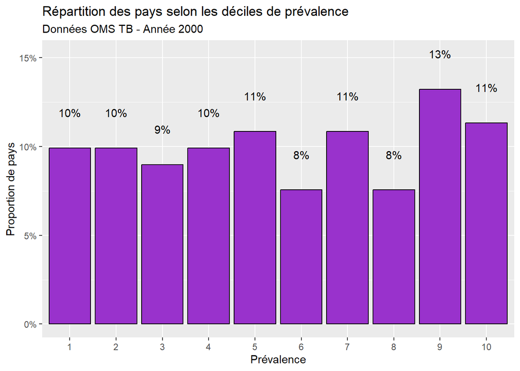

```r
# Graphique proportions pour 2000 (style CM)
prev_plot_prop_2000 <- ggplot(TB2_2000) +

  aes(x = prevalence, y = after_stat(prop)) +  # on calcule les proportions

  geom_bar(stat = "prop", fill = "darkorchid", colour = "black") +

  scale_y_continuous(labels = scales::label_percent()) +
  xlab("Prévalence") +

  ylab("Proportion de pays") +

  geom_text(
    stat = "prop",
    aes(label = scales::percent(after_stat(prop), accuracy = 1)),
    nudge_y = 0.02
  ) +

  ggtitle("Répartition des pays selon les déciles de prévalence",
          subtitle = "Données OMS TB - Année 2000")

# Affichage
prev_plot_prop_2000
```

#I.1.2) Incidence ## Quantiles et écarts interquantiles ##pour estimated inc

```r
quantiles_inc <- quantile(TB2$`Estimated_incidence_(all_forms)_per_100_000_population` ,
                      probs = c(0.25, 0.5, 0.75), na.rm = TRUE)

# Calcul de l'écart interquartile (IQR)
iqr_inc <- IQR(TB2$`Estimated_incidence_(all_forms)_per_100_000_population`, na.rm = TRUE)

# Afficher les résultats
quantiles_inc
```

```
## 25% 50% 75%
##  17  61 183
```

```r
iqr_inc
```

```
## [1] 166
```

## Tableau de fréquence incidence

```r
qual_inc<-TB2_2000 %>%select(incidence) %>%st(out = "return")
qual_inc
```

```
##     Variable   N Percent
## 1  incidence 212
## 2      ... 1  25     12%
## 3      ... 2  18      8%
## 4      ... 3  21     10%
## 5      ... 4  20      9%
## 6      ... 5  21     10%
## 7      ... 6  15      7%
## 8      ... 7  23     11%
## 9      ... 8  22     10%
## 10     ... 9  22     10%
## 11    ... 10  25     12%
```

```r
#pour avoir un tableau plus beau
as.data.frame(qual_inc) %>%
#pour transformer en data frame
  kableExtra::kable("html", caption = "📊 Tableau 1 – Statistiques de la variable incidence année 2000") %>%
  kableExtra::kable_styling(full_width = FALSE, bootstrap_options = c("striped", "hover"))
```

📊 Tableau 1 – Statistiques de la variable incidence année 2000

| Variable | N | Percent |
| --- | --- | --- |
| incidence | 212 |  |
| … 1 | 25 | 12% |
| … 2 | 18 | 8% |
| … 3 | 21 | 10% |
| … 4 | 20 | 9% |
| … 5 | 21 | 10% |
| … 6 | 15 | 7% |
| … 7 | 23 | 11% |
| … 8 | 22 | 10% |
| … 9 | 22 | 10% |
| … 10 | 25 | 12% |

## Diagrame en barre incidence

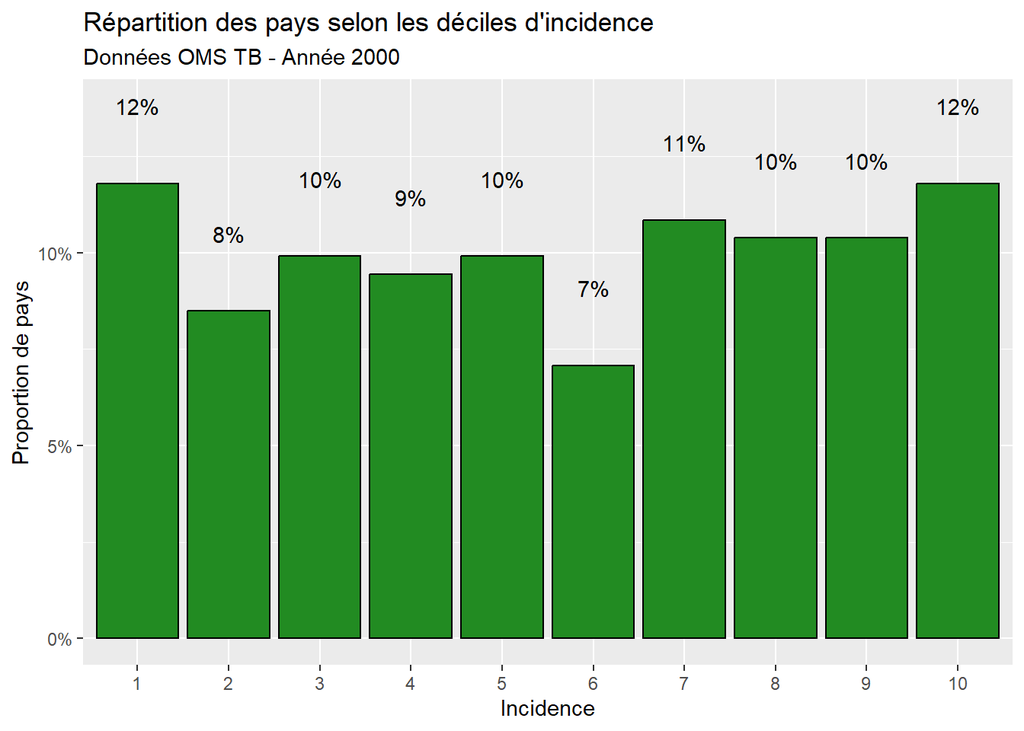

```r
# Graphique proportions pour 2000 (style CM)
inc_plot_prop_2000 <- ggplot(TB2_2000) +

  aes(x = incidence, y = after_stat(prop)) +  # on calcule les proportions

  geom_bar(stat = "prop", fill = "#228B22", colour = "black") +

  scale_y_continuous(labels = scales::label_percent()) +
  xlab("Incidence") +

  ylab("Proportion de pays") +

  geom_text(
    stat = "prop",
    aes(label = scales::percent(after_stat(prop), accuracy = 1)),
    nudge_y = 0.02
  ) +

  ggtitle("Répartition des pays selon les déciles d'incidence",
          subtitle = "Données OMS TB - Année 2000")

# Affichage
inc_plot_prop_2000
```

#I.1.3) Région

## Tableau de fréquence région

#region

```r
qual_region <- TB2_2000 %>%
  select(region_facteur) %>%
  st(out = "return")

as.data.frame(qual_region) %>%
  kable("html", caption = "📊 Statistiques de la variable `region_facteur` – Année 2000") %>%
  kable_styling(full_width = FALSE, bootstrap_options = c("striped", "hover"))
```

📊 Statistiques de la variable `region_facteur` – Année 2000

| Variable | N | Percent |
| --- | --- | --- |
| region_facteur | 212 |  |
| … AFR | 46 | 22% |
| … AMR | 45 | 21% |
| … EMR | 22 | 10% |
| … EUR | 53 | 25% |
| … SEA | 10 | 5% |
| … WPR | 36 | 17% |

## Diagrame en barre région

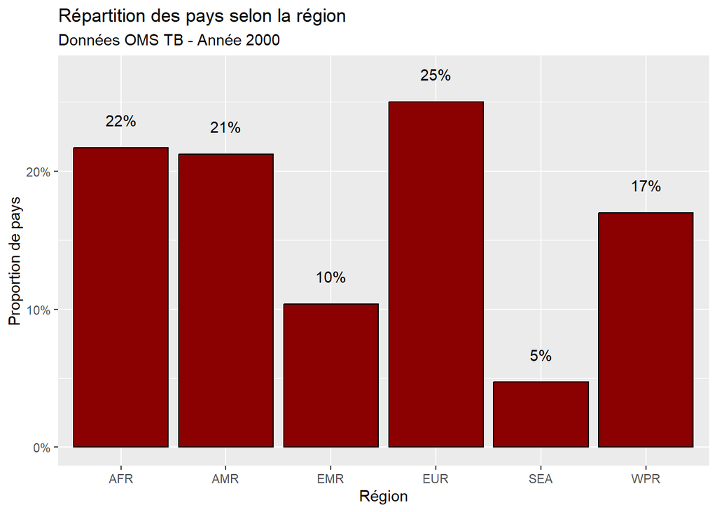

```r
# Graphique proportions pour 2000 (style CM)
reg_plot_prop_2000 <- ggplot(TB2_2000) +

  aes(x = region_facteur, y = after_stat(prop)) +  # on calcule les proportions

  geom_bar(stat = "prop", fill = "darkred", colour = "black") +

  scale_y_continuous(labels = scales::label_percent()) +
  xlab("Région") +

  ylab("Proportion de pays") +

  geom_text(
    stat = "prop",
    aes(label = scales::percent(after_stat(prop), accuracy = 1)),
    nudge_y = 0.02
  ) +

  ggtitle("Répartition des pays selon la région",
          subtitle = "Données OMS TB - Année 2000")

# Affichage
reg_plot_prop_2000
```

#I.1.4) methode to derive mortality ## Quantiles et écarts interquantiles ???Pas trouvé ## Tableau de fréquence methode to derive mortality

```r
qual_method_mort <- TB2 %>%
  filter(Year == 2000) %>%
  select(Method_to_derive_mortality_estimates) %>%
  st(out = "return")

as.data.frame(qual_method_mort) %>%
  kable("html", caption = "📊 Statistiques de la variable `Method_to_derive_mortality` – Année 2000") %>%
  kable_styling(full_width = FALSE, bootstrap_options = c("striped", "hover"))
```

📊 Statistiques de la variable `Method_to_derive_mortality` – Année 2000

| Variable | N | Percent |
| --- | --- | --- |
| Method_to_derive_mortality_estimates | 212 |  |
| … Indirect | 87 | 41% |
| … VR | 104 | 49% |
| … VR imputed | 21 | 10% |

## Diagrame en barre methode to derive mortality

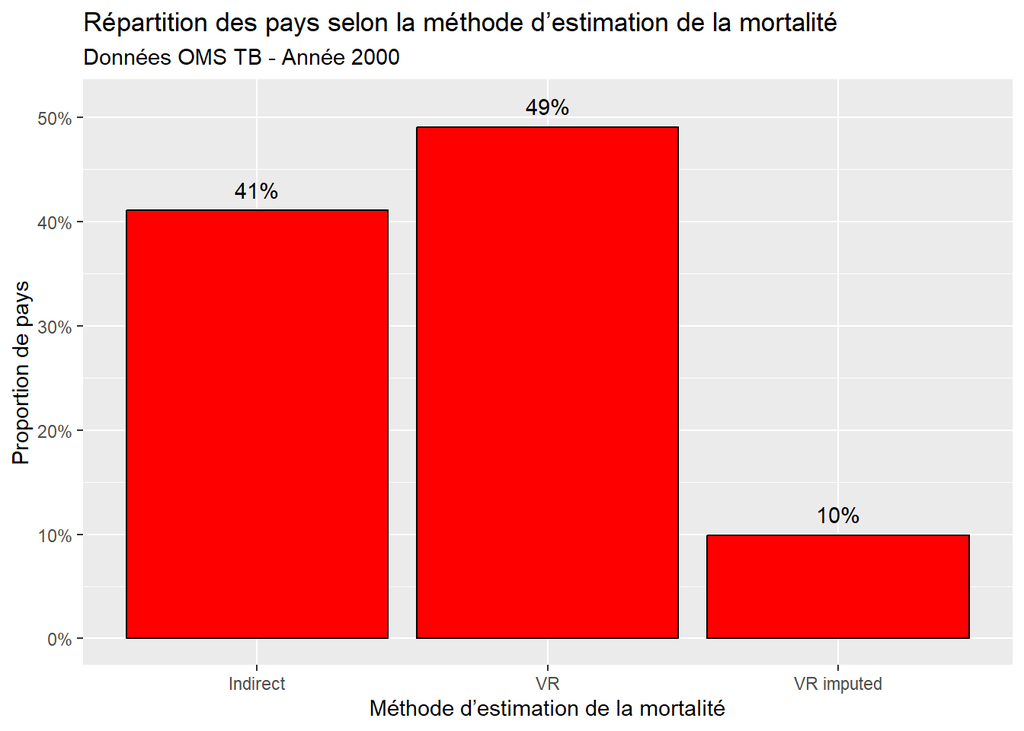

```r
# Graphique proportions pour 2000 (style CM)
mort_plot_prop_2000 <- ggplot(TB2_2000) +

  aes(x = Method_to_derive_mortality_estimates, y = after_stat(prop)) +  # on calcule les proportions

  geom_bar(stat = "prop", fill = "red", colour = "black") +

  scale_y_continuous(labels = scales::label_percent()) +
  xlab("Méthode d’estimation de la mortalité") +

  ylab("Proportion de pays") +

  geom_text(
    stat = "prop",
    aes(label = scales::percent(after_stat(prop), accuracy = 1)),
    nudge_y = 0.02
  ) +

  ggtitle("Répartition des pays selon la méthode d’estimation de la mortalité",
          subtitle = "Données OMS TB - Année 2000")

# Affichage
mort_plot_prop_2000
```

#I.1.5) methode to derive prevalence ##Tableau de fréquence methode to derive prevalence

```r
qual_method_prev <- TB2_2000 %>%
  select(Method_to_derive_prevalence_estimates) %>%
  st(out = "return")

as.data.frame(qual_method_prev) %>%
  kable("html", caption = "📊 Statistiques de la variable `Method_to_derive_prevalence` – Année 2000") %>%
  kable_styling(full_width = FALSE, bootstrap_options = c("striped", "hover"))
```

📊 Statistiques de la variable `Method_to_derive_prevalence` – Année 2000

| Variable | N | Percent |
| --- | --- | --- |
| Method_to_derive_prevalence_estimates | 212 |  |
| … NTP | 2 | 1% |
| … predicted | 197 | 93% |
| … survey | 1 | 0% |
| … survey imputed | 12 | 6% |

## Diagramme en barre method to derive prevalence

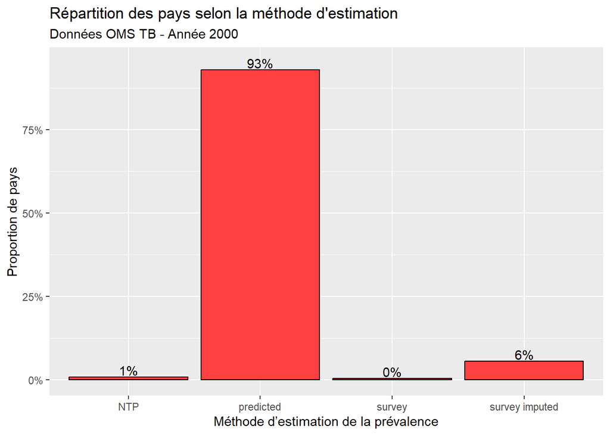

```r
# Graphique proportions pour 2000 (style CM)
mort_plot_prop_2000 <- ggplot(TB2_2000) +

  aes(x = Method_to_derive_prevalence_estimates, y = after_stat(prop)) +  # on calcule les proportions

  geom_bar(stat = "prop", fill = "brown1", colour = "black") +

  scale_y_continuous(labels = scales::label_percent()) +
  xlab("Méthode d’estimation de la prévalence") +

  ylab("Proportion de pays") +

  geom_text(
    stat = "prop",
    aes(label = scales::percent(after_stat(prop), accuracy = 1)),
    nudge_y = 0.02
  ) +

  ggtitle("Répartition des pays selon la méthode d'estimation",
          subtitle = "Données OMS TB - Année 2000")

# Affichage
mort_plot_prop_2000
```

#I.1.6) det case ##Tableau de fréquence det case

```r
qual_case <- TB2 %>%
  filter(Year == 2000) %>%
  select(det_case) %>%
  st(out = "return")

as.data.frame(qual_case) %>%
  kable("html", caption = "📊 Statistiques de la variable `det_case` – Année 2000") %>%
  kable_styling(full_width = FALSE, bootstrap_options = c("striped", "hover"))
```

📊 Statistiques de la variable `det_case` – Année 2000

| Variable | N | Percent |
| --- | --- | --- |
| det_case | 212 |  |
| … Bon | 103 | 49% |
| … Correct | 39 | 18% |
| … Insuffisant | 50 | 24% |
| … Non renseignée | 20 | 9% |

#Diagramme en barre #incidence

```r
pacman::p_load(ggstats, scales)
```

J’esssaie cette fois ci en gardant juste l’annee 2000 #INCIDENCE

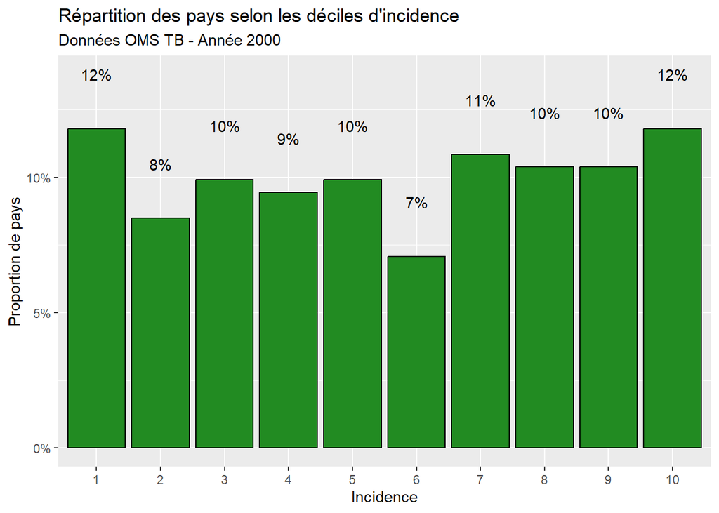

```r
# On filtre les données pour l'année 2000
TB2_2000 <- TB2 %>% filter(Year == 2000)

# Graphique proportions pour 2000 (style CM)
inc_plot_prop_2000 <- ggplot(TB2_2000) +

  aes(x = incidence, y = after_stat(prop)) +  # on calcule les proportions

  geom_bar(stat = "prop", fill = "#228B22", colour = "black") +

  scale_y_continuous(labels = scales::label_percent()) +
  xlab("Incidence") +

  ylab("Proportion de pays") +

  geom_text(
    stat = "prop",
    aes(label = scales::percent(after_stat(prop), accuracy = 1)),
    nudge_y = 0.02
  ) +

  ggtitle("Répartition des pays selon les déciles d'incidence",
          subtitle = "Données OMS TB - Année 2000")

# Affichage
inc_plot_prop_2000
```

## Diagramme en barre det case

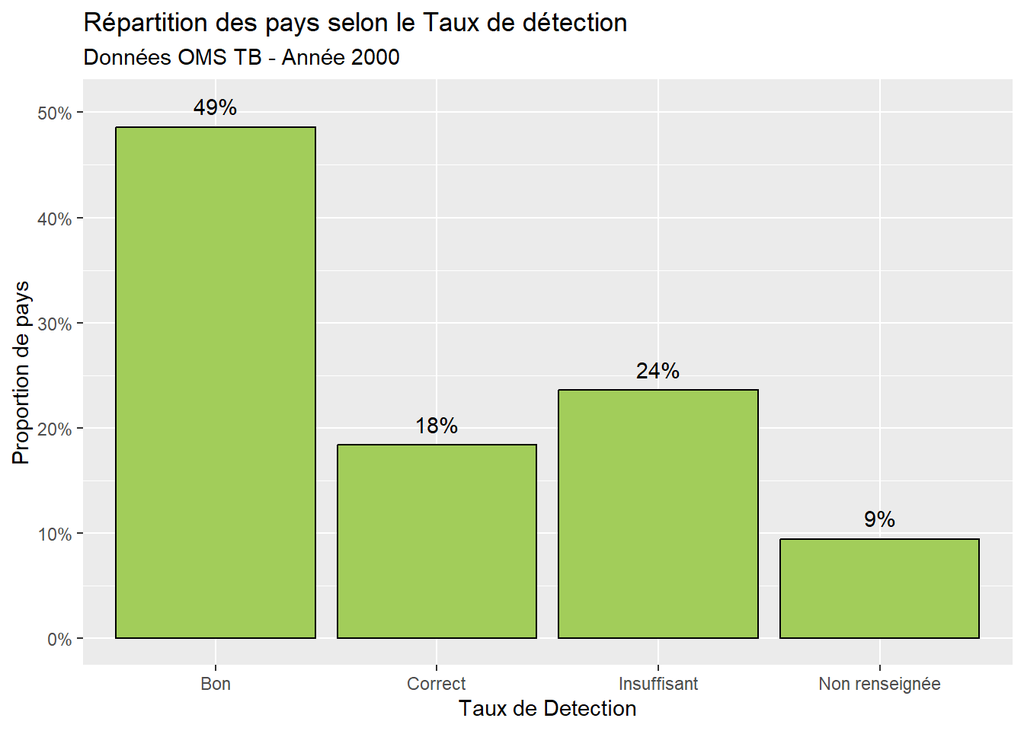

```r
# Graphique proportions pour 2000 (style CM)
case_plot_prop_2000 <- ggplot(TB2_2000) +

  aes(x = det_case, y = after_stat(prop)) +  # on calcule les proportions

  geom_bar(stat = "prop", fill = "darkolivegreen3", colour = "black") +

  scale_y_continuous(labels = scales::label_percent()) +
  xlab("Taux de Detection") +

  ylab("Proportion de pays") +

  geom_text(
    stat = "prop",
    aes(label = scales::percent(after_stat(prop), accuracy = 1)),
    nudge_y = 0.02
  ) +

  ggtitle("Répartition des pays selon le Taux de détection",
          subtitle = "Données OMS TB - Année 2000")

# Affichage
case_plot_prop_2000
```

#II) Analyse bivarié #II.1) Analyse bivarié de nos variables quantitatives ##II.1.1) incidence & prévalence

##nuage de points

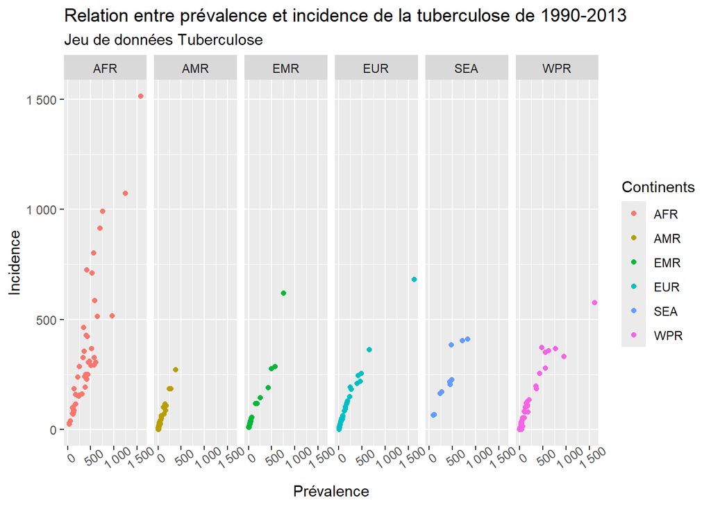

```r
ggplot(TB2_2000)+
  aes(x=`Estimated_prevalence_of_TB_(all_forms)_per_100_000_population`,
      y= `Estimated_incidence_(all_forms)_per_100_000_population`,
      colour= Region)+
  geom_point()+
  labs(
    x="Prévalence",
    y="Incidence",
    colour="Continents"
  )+
  ggtitle("Relation entre prévalence et incidence de la tuberculose de 1990-2013",
          subtitle = "Jeu de données Tuberculose")+
  scale_x_continuous(labels = scales::label_number(decimal.mark=","))+
  scale_y_continuous(
    labels = scales::label_number(decimal.mark=",")
  )+
  facet_grid(cols=vars(Region))+
  theme(axis.text.x=element_text(angle=35))
```

### Analyse

1. Description du graphique : Axe X (Prévalence) : Il représente la prévalence de la tuberculose par 100 000 habitants.

Axe Y (Incidence) : Il représente le nombre de nouveaux cas de tuberculose (incidence) par 100 000 habitants.

Couleur des points : Chaque continent est représenté par une couleur différente (par exemple, rouge pour l’Afrique, bleu pour l’Europe, etc.).

Facettes : Le graphique est divisé en plusieurs facettes, chacune représentant un continent, ce qui permet de comparer la relation entre prévalence et incidence dans chaque région.

2. Interprétation du graphique : Pour la plupart des continents, il existe une relation positive entre la prévalence et l’incidence, c’est-à-dire que les pays avec une prévalence élevée de la tuberculose ont également une incidence élevée. Cela montre que dans ces régions, une plus grande proportion de la population est touchée par la tuberculose, et donc de nouveaux cas continuent d’apparaître.

Cependant, des variations peuvent être observées selon les continents :

Certains continents comme l’Afrique (représentée en rouge) ont des points assez dispersés, ce qui pourrait indiquer une hétérogénéité dans la relation entre prévalence et incidence.

D’autres continents, comme l’Europe (en bleu), montrent une relation plus linéaire, avec une forte correspondance entre la prévalence et l’incidence.

3. Conclusion : Le graphique montre que la prévalence et l’incidence sont généralement liées, mais la force de cette relation varie selon les régions. Les différences entre les continents peuvent être dues à des facteurs socio-économiques, des politiques de santé ou des pratiques de diagnostic variables.

Il serait intéressant d’explorer ces relations plus en détail pour chaque région afin de comprendre les facteurs spécifiques influençant la tuberculose dans ces zones.

En résumé, la prévalence et l’incidence de la tuberculose sont liées, mais le modèle de cette relation varie d’un continent à l’autre.

## covariance

```r
TB2_2000 %>% select(`Estimated_prevalence_of_TB_(all_forms)_per_100_000_population`, `Estimated_incidence_(all_forms)_per_100_000_population`)%>%cov()
```

```
##                                                               Estimated_prevalence_of_TB_(all_forms)_per_100_000_population
## Estimated_prevalence_of_TB_(all_forms)_per_100_000_population                                                      79120.66
## Estimated_incidence_(all_forms)_per_100_000_population                                                             51515.90
##                                                               Estimated_incidence_(all_forms)_per_100_000_population
## Estimated_prevalence_of_TB_(all_forms)_per_100_000_population                                               51515.90
## Estimated_incidence_(all_forms)_per_100_000_population                                                      43704.07
```

2. Interprétation des résultats : Covariance de la prévalence avec elle-même : 79120.66

La covariance d’une variable avec elle-même est égale à la variance de cette variable. Cela montre à quel point les valeurs de prévalence varient par rapport à leur moyenne.

Covariance entre la prévalence et l’incidence : 51515.90

La covariance positive montre que lorsque la prévalence de la tuberculose augmente, l’incidence tend également à augmenter (et vice versa). Cela confirme une relation positive entre les deux variables.

Covariance de l’incidence avec elle-même : 43704.07

La covariance de l’incidence avec elle-même est la variance de l’incidence. Elle donne une idée de la dispersion des valeurs d’incidence autour de leur moyenne.

3. Conclusion : La covariance positive entre la prévalence et l’incidence (51515.90) confirme qu’il y a une relation directe entre ces deux variables : à mesure que l’incidence de la tuberculose augmente, la prévalence tend également à augmenter.

Cette information, bien que précieuse, n’est pas suffisante pour évaluer l’intensité de cette relation, car la covariance dépend des unités des variables. Pour obtenir une mesure normalisée de la force de la relation, il serait préférable de calculer le coefficient de corrélation entre ces variables.

##coefficient de corrélation pearson

```r
cor(x=TB2_2000[["Estimated_prevalence_of_TB_(all_forms)_per_100_000_population"]], y=TB2_2000[["Estimated_incidence_(all_forms)_per_100_000_population"]], method ="pearson")
```

```
## [1] 0.8760633
```

##coefficient de corrélation Spearman

```r
cor(x=TB2_2000[["Estimated_prevalence_of_TB_(all_forms)_per_100_000_population"]], y=TB2_2000[["Estimated_incidence_(all_forms)_per_100_000_population"]], method ="spearman")
```

```
## [1] 0.9833881
```

### Analyse

1. Coefficient de corrélation de Pearson : 0.876 Un coefficient de 0.876 indique une relation positive forte et linéaire entre la prévalence et l’incidence de la tuberculose. Cela signifie que, à mesure que la prévalence de la tuberculose augmente, l’incidence tend également à augmenter de manière linéaire et relativement forte.

La valeur proche de 1 montre que la relation linéaire entre ces deux variables est assez bien définie.

2. Coefficient de corrélation de Spearman : 0.983 Un coefficient de 0.983 pour Spearman indique une relation monotone très forte entre la prévalence et l’incidence de la tuberculose. Cela signifie que, bien que la relation ne soit pas nécessairement linéaire, les deux variables évoluent de manière très similaire (à mesure que l’une augmente, l’autre tend à augmenter aussi de manière régulière).

La valeur proche de 1 montre que la relation monotone entre ces deux variables est extrêmement forte.

Conclusion : Pearson (0.876) suggère une forte relation linéaire entre la prévalence et l’incidence, ce qui indique que l’augmentation de la prévalence est associée à une augmentation linéaire de l’incidence.

Spearman (0.983) montre une relation monotone très forte, ce qui signifie que la prévalence et l’incidence ont une tendance générale à augmenter ou diminuer ensemble, même si cette relation n’est pas strictement linéaire.

Dans les deux cas, il y a une forte corrélation entre la prévalence et l’incidence de la tuberculose, mais Spearman montre que la relation est encore plus robuste en termes de monotonie.

##regression linéaire

```r
prevalence_vs_incidence<-TB2_2000%>%
  lm(`Estimated_prevalence_of_TB_(all_forms)_per_100_000_population` ~
       `Estimated_incidence_(all_forms)_per_100_000_population`,data =.)
summary(prevalence_vs_incidence)
```

```
##
## Call:
## lm(formula = `Estimated_prevalence_of_TB_(all_forms)_per_100_000_population` ~
##     `Estimated_incidence_(all_forms)_per_100_000_population`,
##     data = .)
##
## Residuals:
##     Min      1Q  Median      3Q     Max
## -477.67  -36.92  -29.98    7.14  903.14
##
## Coefficients:
##                                                          Estimate Std. Error
## (Intercept)                                              38.08098   11.42237
## `Estimated_incidence_(all_forms)_per_100_000_population`  1.17874    0.04477
##                                                          t value Pr(>|t|)
## (Intercept)                                                3.334  0.00101 **
## `Estimated_incidence_(all_forms)_per_100_000_population`  26.328  < 2e-16 ***
## ---
## Signif. codes:  0 '***' 0.001 '**' 0.01 '*' 0.05 '.' 0.1 ' ' 1
##
## Residual standard error: 136 on 210 degrees of freedom
## Multiple R-squared:  0.7675, Adjusted R-squared:  0.7664
## F-statistic: 693.2 on 1 and 210 DF,  p-value: < 2.2e-16
```

### Analyse

Tout d’abord, les résidus représentent la différence entre les valeurs observées et les valeurs prédites par le modèle. On peut voir que le minimum est de -477.67, le 1er quartile est de -36.92, la médiane est de -29.98 et le 3ème quartile est de 7.14 ainsi que le maximum est de 903.14. On constate donc que les résidus sont relativement éparpillés, il y a surement une certaine variabilité dans les erreurs de prédiction, mais cela ne semble pas très biaisé.

Relation entre les variables : La prévalence de la tuberculose (toutes formes) est positivement liée à l’incidence de la tuberculose.

Significativité : Le p-value de la variable indépendante (incidence de la tuberculose) est très faible (< 2e-16), ce qui signifie que cette relation est hautement significative.

L’intercept est également significatif, avec une p-value de 0.00101.

R-squared : Le modèle explique 76.75% de la variance dans la prévalence de la tuberculose, ce qui montre que l’incidence est un facteur très important pour prédire la prévalence dans ce modèle.

F-statistic : Le F-statistic est élevé (693.2) avec une p-value très faible, indiquant que le modèle est globalement significatif et que la relation entre les deux variables est robuste.

Conclusion : L’incidence de la tuberculose est un prédicteur très significatif de la prévalence de la tuberculose dans la population générale, avec un modèle qui explique 76.75% de la variance de la prévalence.

##résidus versus valeurs ajustées

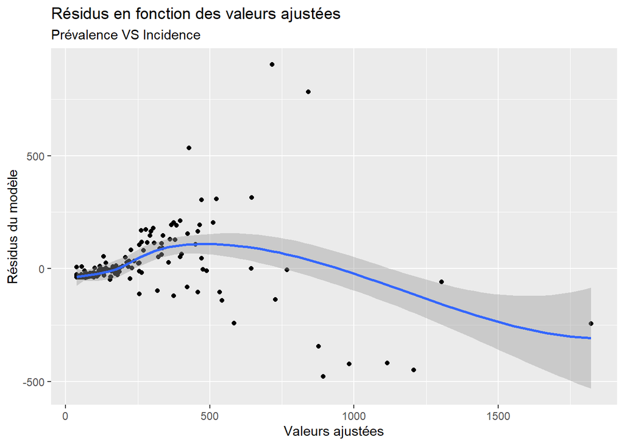

```r
ggplot() +
  aes(x = fitted(prevalence_vs_incidence), y = residuals(prevalence_vs_incidence)) +
  geom_point() +
  geom_smooth() +
  xlab("Valeurs ajustées") +
  ylab("Résidus du modèle") +
  ggtitle("Résidus en fonction des valeurs ajustées", subtitle = "Prévalence VS Incidence")
```

### Analyse

La courbe lissée indique une forme non linéaire des résidus par rapport aux valeurs ajustées. Cela suggère qu’un modèle linéaire ne s’adapte pas parfaitement aux données, car les erreurs de prédiction ne sont pas distribuées de manière homogène à travers les différentes valeurs ajustées.

Le graphique révèle que la relation entre les prévalence et incidence de la tuberculose est probablement plus complexe qu’une simple relation linéaire, avec des résidus non homogènes à travers les différentes valeurs ajustées. Il serait conseillé d’explorer des modèles non linéaires ou d’utiliser des transformations pour stabiliser la variance des erreurs et obtenir un meilleur ajustement.

##qqplot

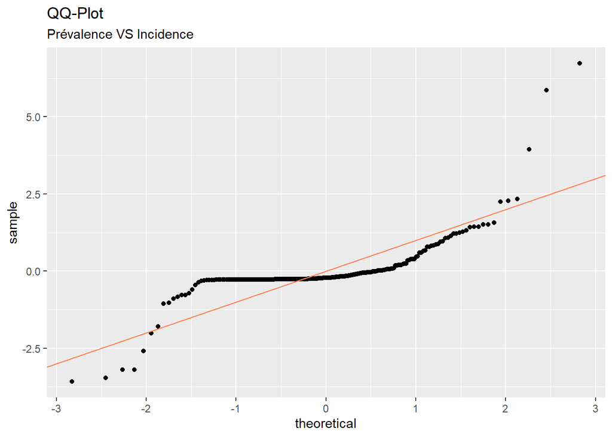

```r
ggplot() +
  geom_qq(aes(sample=rstandard(prevalence_vs_incidence)))+
  geom_abline(color="coral")+
  ggtitle("QQ-Plot", subtitle="Prévalence VS Incidence")
```

### Analyse :

Le QQ-plot montre la distribution des résidus standardisés de notre modèle de régression par rapport à une distribution normale théorique.

1. Analyse du graphique : Axe théorique : Il représente les quantiles de la distribution normale théorique.

Axe des échantillons (sample) : Il représente les quantiles des résidus standardisés du modèle de régression.

Écarts aux extrémités : Les points commencent à s’éloigner de la droite aux extrémités (dans les valeurs négatives et positives élevées). Cela suggère que les résidus présentent des queues plus lourdes que ce que l’on attend d’une distribution normale, ce qui pourrait indiquer une asymétrie ou la présence de valeurs extrêmes (outliers).

##scale-location (position-échelle)

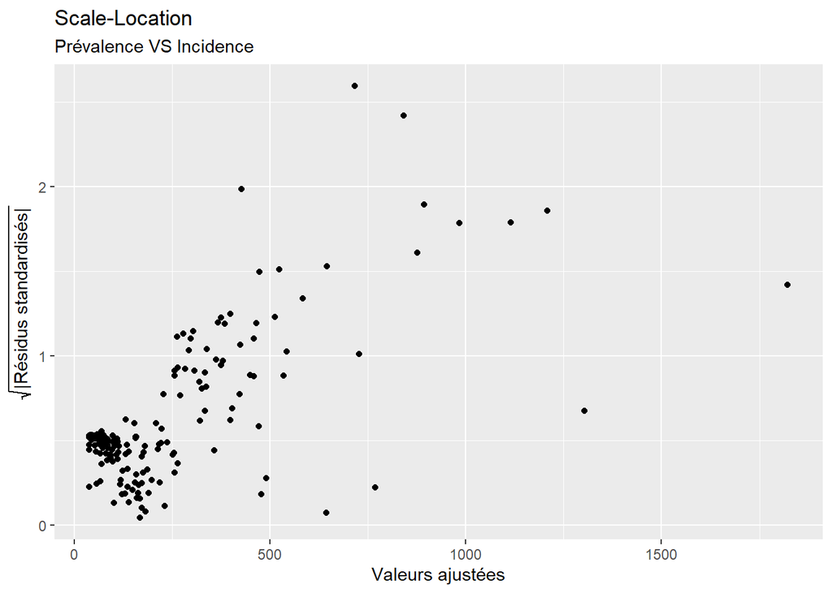

```r
ggplot() +
  aes(x = fitted(prevalence_vs_incidence), y = sqrt(abs(rstandard(prevalence_vs_incidence)))) +
  geom_point()  +
  xlab("Valeurs ajustées") +
  ylab(expression(sqrt("|Résidus standardisés|"))) +
  ggtitle("Scale-Location", subtitle="Prévalence VS Incidence")
```

### Analyse

Ce graphique montre la relation entre les valeurs ajustées (prédictions du modèle) et les résidus standardisés (échelles transformées par la racine carrée des résidus absolus). Il permet de vérifier si l’hypothèse d’homoscédasticité (variance constante des résidus) est respectée dans le modèle de régression.

1. Description du graphique : Axe X (Valeurs ajustées) : Les valeurs ajustées représentent les prédictions du modèle pour chaque observation, c’est-à-dire la prévalence estimée de la tuberculose en fonction de l’incidence.

Axe Y (Résidus standardisés) : Les résidus standardisés, transformés par la racine carrée de la valeur absolue des résidus, permettent de mieux visualiser la dispersion des erreurs et de vérifier l’homoscédasticité.

Il pourrait être utile de vérifier ces points ou d’explorer des modèles non linéaires ou robustes pour ces observations spécifiques.

## distance de cook

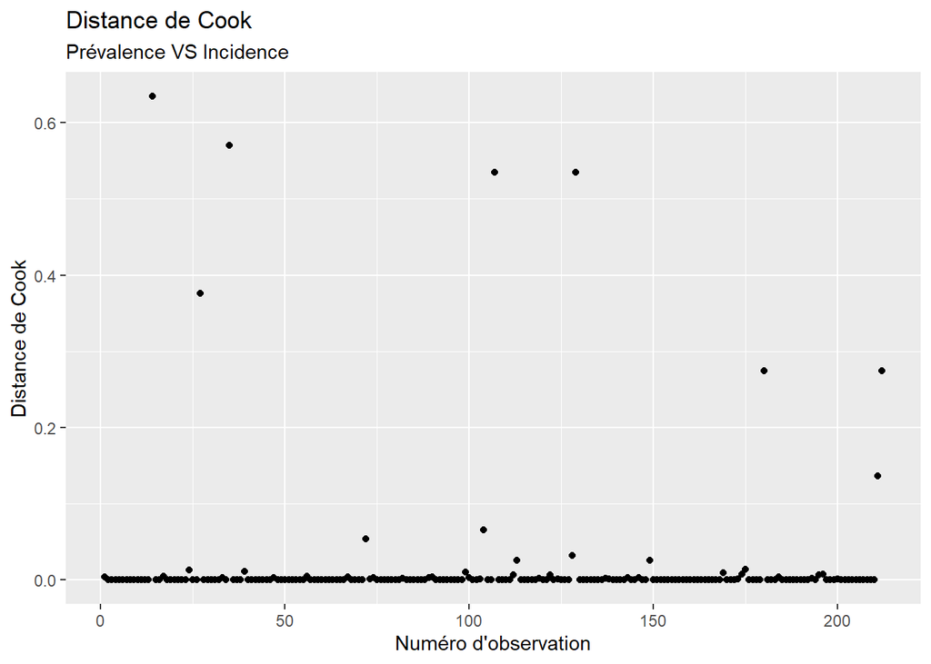

```r
ggplot() +
  aes(x =seq_along(cooks.distance(prevalence_vs_incidence)), y = cooks.distance(prevalence_vs_incidence)) +
  geom_point()  +
  xlab("Numéro d'observation") +
  ylab("Distance de Cook") +
  ggtitle("Distance de Cook", subtitle="Prévalence VS Incidence")
```

### Analyse

Il pourrait être utile de vérifier ces points ou d’explorer des modèles non linéaires ou robustes pour ces observations spécifiques.

##residual versus leverage

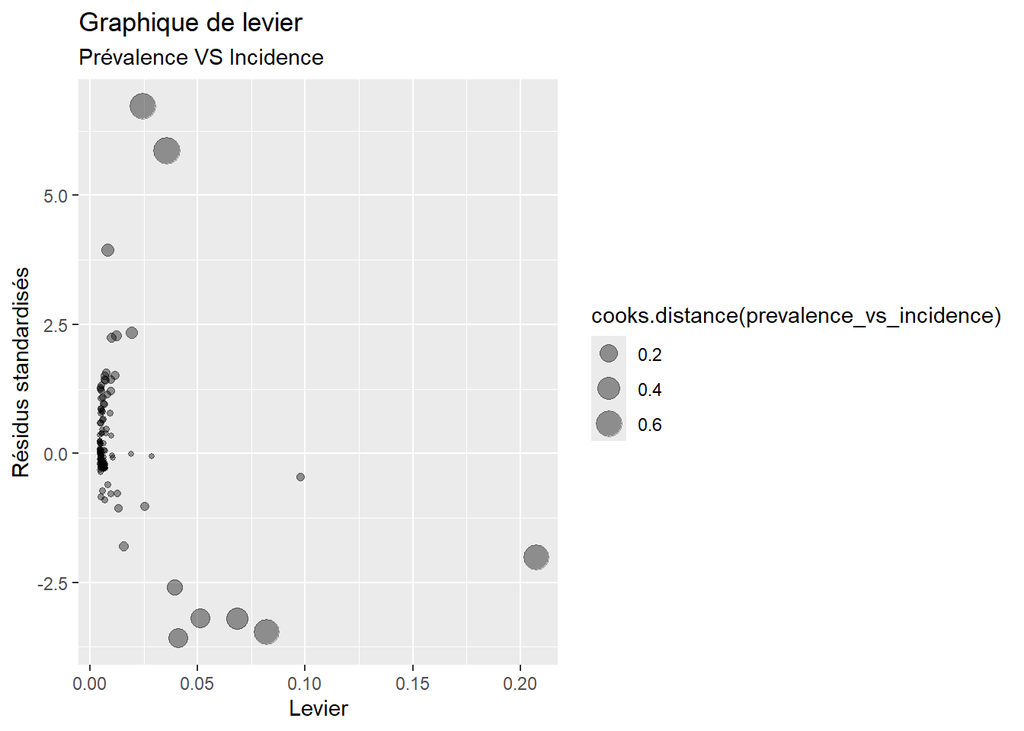

```r
ggplot() +
  aes(x =hatvalues(prevalence_vs_incidence), y = rstandard(prevalence_vs_incidence)) +
  geom_point(aes(size=cooks.distance(prevalence_vs_incidence)),alpha=0.4)  +
  xlab("Levier") +
  ylab("Résidus standardisés") +
  ggtitle("Graphique de levier", subtitle="Prévalence VS Incidence")
```

### Analyse

1. Description du graphique : Axe X (Levier) : Le levier mesure l’influence d’une observation sur les valeurs ajustées du modèle. Un levier élevé signifie qu’une observation est éloignée de la moyenne des autres observations.

Axe Y (Résidus standardisés) : Les résidus standardisés mesurent l’écart entre les valeurs observées et les valeurs ajustées, normalisé pour tenir compte de la variance des erreurs.

Les cercles de taille variable représentent la distance de Cook de chaque observation. Plus le cercle est grand, plus l’observation a un impact important sur le modèle.

2. Interprétation du graphique : La majorité des observations ont une distance de Cook faible, ce qui suggère qu’elles n’ont pas une influence excessive sur le modèle. Ces points sont proches de la ligne de régression et n’affectent pas de manière significative les résultats du modèle.

3. Conclusion : Le graphique montre qu’une petite fraction des observations ont une influence significative sur le modèle. Ces points pourraient être des outliers ou des observations particulières qui doivent être vérifiées de plus près.